# Setup

### TMB

```r
mod <- '
#include <TMB.hpp>

template<class Type>
Type objective_function<Type>::operator() ()
{

  using namespace density;

  DATA_VECTOR(y);
  DATA_VECTOR(E);

  DATA_MATRIX(Aconstr);
  DATA_SPARSE_MATRIX(Z_space_time);
  DATA_SPARSE_MATRIX(R_time);
  DATA_SPARSE_MATRIX(R_space);

  Type val(0);

  PARAMETER(beta0);
  // beta0 ~ 1

  PARAMETER(log_prec_space_time);
  val -= dlgamma(log_prec_space_time, Type(0.001), Type(1.0 / 0.001), true);
  Type sigma_space_time(exp(-0.5 * log_prec_space_time));

  PARAMETER_ARRAY(u_raw_space_time);
  vector<Type> u_raw_space_time_v(u_raw_space_time);
  vector<Type> u_space_time(u_raw_space_time * sigma_space_time);

  val += SEPARABLE(GMRF(R_time), GMRF(R_space))(u_raw_space_time);
  val -= dnorm(Aconstr * u_raw_space_time_v, Type(0), Type(0.001) * u_raw_space_time.cols(), true).sum();  // soft sum-to-zero constraint

  vector<Type> mu(beta0 +
                  Z_space_time * u_space_time +
                  log(E));
  val -= dpois(y, exp(mu), true).sum();

  ADREPORT(u_space_time);

  return val;
}
'

dll <- tmb_compile_and_load(mod)

R_space_time_adj <- R_space_time + Matrix::Diagonal(ncol(R_space_time), 1e-6)

tmbdata <- list(y = data$Observed,
                E = data$Expected,
                Aconstr = Aconstr,
                Z_space_time = Matrix::sparse.model.matrix(~0 + IDf:Yearf, data),
                R_space = R_space_scaled_adj,
                R_time = R_time_scaled_adj)

tmbpar <- list(beta0 = 0,
               log_prec_space_time = 0,
               u_raw_space_time = array(0, c(nrow(tmbdata$R_space), nrow(tmbdata$R_time))))

obj <- TMB::MakeADFun(data = tmbdata,
                      parameters = tmbpar,
                      random = c("beta0", "u_raw_space_time"),
                      DLL = dll)
```

```
## Constructing atomic D_lgamma
## Constructing atomic D_lgamma
```

```r
tmbfit <- nlminb(obj$par, obj$fn, obj$gr)
```

```
## Constructing atomic D_lgamma
## Optimizing tape... Done
## iter: 1  value: 974.4167 mgc: 10.896 ustep: 1
## iter: 2  value: 971.7561 mgc: 57.31864 ustep: 1
## iter: 3  value: 971.7487 mgc: 2.176861 ustep: 1
## iter: 4  value: 971.7487 mgc: 0.006405788 ustep: 1
## iter: 5  value: 971.7487 mgc: 1.77424e-07 ustep: 1
## iter: 6  mgc: 3.583966e-12
## iter: 1  mgc: 3.583966e-12
## Matching hessian patterns... Done
## outer mgc:  51.36509
## iter: 1  value: 998.4856 mgc: 36.03 ustep: 1
## iter: 2  value: 998.4708 mgc: 4.251493 ustep: 1
## iter: 3  value: 998.4708 mgc: 0.01362611 ustep: 1
## iter: 4  value: 998.4708 mgc: 2.434096e-07 ustep: 1
## iter: 5  mgc: 7.83619e-12
## iter: 1  value: 1023.227 mgc: 29.74108 ustep: 1
## iter: 2  value: 1023.211 mgc: 4.475038 ustep: 1
## iter: 3  value: 1023.211 mgc: 0.01510442 ustep: 1
## iter: 4  value: 1023.211 mgc: 2.453362e-07 ustep: 1
## iter: 5  mgc: 4.01168e-12
## iter: 1  mgc: 4.01168e-12
## outer mgc:  16.85745
## iter: 1  value: 1034.251 mgc: 17.68175 ustep: 1
## iter: 2  value: 1034.245 mgc: 2.724553 ustep: 1
## iter: 3  value: 1034.245 mgc: 0.006249126 ustep: 1
## iter: 4  value: 1034.245 mgc: 5.1189e-08 ustep: 1
## iter: 5  mgc: 9.317491e-12
## iter: 1  mgc: 9.317491e-12
## outer mgc:  11.71581
## iter: 1  value: 1043.579 mgc: 20.77269 ustep: 1
## iter: 2  value: 1043.555 mgc: 5.579564 ustep: 1
## iter: 3  value: 1043.555 mgc: 0.02220454 ustep: 1
## iter: 4  value: 1043.555 mgc: 4.66839e-07 ustep: 1
## iter: 5  mgc: 2.452663e-11
## iter: 1  mgc: 2.452663e-11
## outer mgc:  6.458463
## iter: 1  value: 1063.719 mgc: 17.72654 ustep: 1
## iter: 2  value: 1063.715 mgc: 2.683073 ustep: 1
## iter: 3  value: 1063.715 mgc: 0.003788552 ustep: 1
```

[output cut: 20 more lines]

```
## iter: 2  value: 1049.951 mgc: 6.478782e-05 ustep: 1
## iter: 3  mgc: 3.978195e-11
## iter: 1  mgc: 3.978195e-11
## outer mgc:  0.001175169
## iter: 1  value: 1049.952 mgc: 0.002633725 ustep: 1
## iter: 2  value: 1049.952 mgc: 6.226748e-08 ustep: 1
## iter: 3  mgc: 6.109112e-11
## iter: 1  mgc: 6.109112e-11
## outer mgc:  2.436829e-06
## iter: 1  value: 1049.952 mgc: 5.450279e-06 ustep: 1
## iter: 2  mgc: 4.939948e-11
## iter: 1  mgc: 4.939948e-11
## outer mgc:  5.682324e-10
## iter: 1  mgc: 1.270405e-09
## iter: 1  mgc: 4.939948e-11
```

```r
sdr8 <- TMB::sdreport(obj)
```

```
## iter: 1  mgc: 4.939948e-11
## outer mgc:  5.682324e-10
## iter: 1  value: 1049.957 mgc: 0.01128019 ustep: 1
## iter: 2  value: 1049.957 mgc: 1.142425e-06 ustep: 1
## iter: 3  mgc: 4.451989e-11
## outer mgc:  0.005047059
## iter: 1  value: 1049.947 mgc: 0.01128917 ustep: 1
## iter: 2  value: 1049.947 mgc: 1.14381e-06 ustep: 1
## iter: 3  mgc: 3.977547e-11
## outer mgc:  0.005044365
## outer mgc:  0.08597375
```

```r
summary(sdr8, "all")
```

```
##                         Estimate Std. Error
## log_prec_space_time  8.096334574 0.44518321
## beta0               -0.013667418 0.02981683
## u_raw_space_time     2.480252874 6.59982062
## u_raw_space_time     2.588862844 6.69775648
## u_raw_space_time     2.589800875 6.66282071
## u_raw_space_time     2.683932371 6.73485033
## u_raw_space_time     2.976495938 6.82149850
## u_raw_space_time     2.683109497 6.66739530
## u_raw_space_time     2.524070856 6.75495366
## u_raw_space_time     2.633107219 6.75762167
## u_raw_space_time     2.640546116 6.76608505
## u_raw_space_time     2.619034487 6.65116240
## u_raw_space_time     2.686584652 6.69033334
## u_raw_space_time     2.759014993 6.93300204
## u_raw_space_time     2.759595379 6.76048415
## u_raw_space_time     2.618563887 6.62311370
## u_raw_space_time     2.462040272 6.72761570
## u_raw_space_time     2.662542766 6.77624379
## u_raw_space_time     2.629416273 6.72982183
## u_raw_space_time     2.649293272 6.66052972
## u_raw_space_time     2.642930180 6.67209602
## u_raw_space_time     2.712856907 6.64596728
## u_raw_space_time     2.628496461 6.65371474
## u_raw_space_time     2.764027329 6.68814715
## u_raw_space_time     2.541641754 6.62710766
## u_raw_space_time     2.705119566 6.74028684
## u_raw_space_time     2.657703268 6.62998222
## u_raw_space_time     2.567652155 6.61023730
## u_raw_space_time     2.599886841 6.65856018
## u_raw_space_time     2.558025125 6.64978236
## u_raw_space_time     2.653222162 6.75668821
## u_raw_space_time     2.606371079 6.60100746
## u_raw_space_time     2.730836032 6.76704053
## u_raw_space_time     2.619418105 6.61673892
## u_raw_space_time     3.158004996 5.73713327
## u_raw_space_time     3.269554993 5.83518610
## u_raw_space_time     3.271337719 5.80128438
## u_raw_space_time     3.359296062 5.87315111
## u_raw_space_time     3.654473436 5.96193920
```

[output cut: 447 more lines]

```
## u_raw_space_time     5.881305774 5.43287058
## u_raw_space_time     6.139120067 5.29910051
## u_raw_space_time     6.137790289 5.35814232
## u_raw_space_time     6.165493023 5.36482890
## u_raw_space_time     6.136693879 5.36990315
## u_raw_space_time     6.212650972 5.28154305
## u_raw_space_time     6.160449455 5.31452150
## u_raw_space_time     6.045799471 5.50062499
## u_raw_space_time     6.059639442 5.37465155
## u_raw_space_time     6.190497651 5.26134450
## u_raw_space_time     6.331833484 5.32910910
## u_raw_space_time     6.099399477 5.37908126
## u_raw_space_time     6.141455581 5.34262556
## u_raw_space_time     6.189215067 5.28963223
##  [ reached getOption("max.print") -- omitted 718 rows ]
```

Hyper parameter comparison

```r
summary(sdr8, "fixed")
```

```
##                     Estimate Std. Error
## log_prec_space_time 8.096335  0.4451832
```

```r
cbind("mean" = inlafit8$misc$theta.mode,
      "se" = sqrt(diag(inlafit8$misc$cov.intern)))
```

```
##          mean       se
## [1,] 5.997602 1.160312
```

```r
cbind("mean" = inlafit8C$misc$theta.mode,
      "se" = sqrt(diag(inlafit8C$misc$cov.intern)))
```

```
##          mean       se
## [1,] 5.997606 1.160322
```

Fixed effects (Intercept)

```r
summary(sdr8, "random")[1, , drop = FALSE]
```

```
##          Estimate Std. Error
## beta0 -0.01366742 0.02981683
```

```r
inlafit8$summary.fixed[ , 1:2]
```

```
##                    mean         sd
## (Intercept) -0.01943739 0.03001591
```

```r
inlafit8C$summary.fixed[ , 1:2]
```

```
##                    mean         sd
## (Intercept) -0.01943739 0.03001591
```

Random effects mean and standard deviation

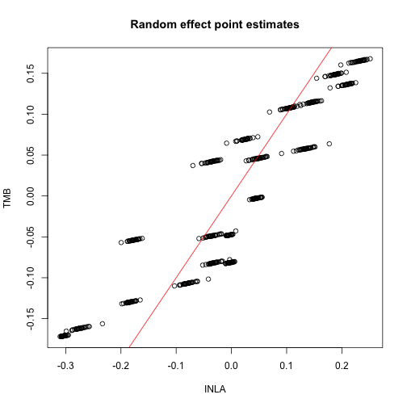

```r
plot(inlafit8C$summary.random[[1]][,2], summary(sdr8, "report")[,1],
     xlab = "INLA", ylab = "TMB", main = "Random effect point estimates")
abline(0, 1, col = "red")
```

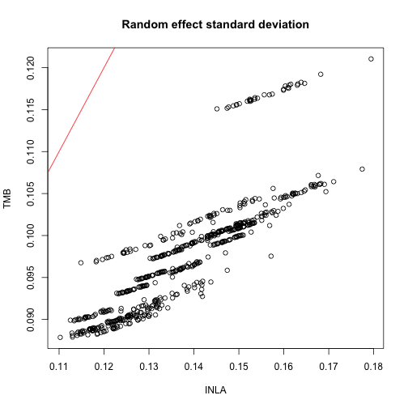

```r
plot(inlafit8C$summary.random[[1]][,3], summary(sdr8, "report")[,2],
     xlab = "INLA", ylab = "TMB", main = "Random effect standard deviation")
abline(0, 1, col = "red")
```

### Model 8b: Explicit sum-to-zero constraint

```r
mod <- '
#include <TMB.hpp>

template<class Type>
Type objective_function<Type>::operator() ()
{

  using namespace density;

  DATA_VECTOR(y);
  DATA_VECTOR(E);

  DATA_MATRIX(L_space_time)
  DATA_SPARSE_MATRIX(Z_space_time);
  DATA_SPARSE_MATRIX(LRL_space_time);

  Type val(0);

  PARAMETER(beta0);
  // beta0 ~ 1

  PARAMETER(log_prec_space_time);
  val -= dlgamma(log_prec_space_time, Type(0.001), Type(1.0 / 0.001), true);
  Type sigma_space_time(exp(-0.5 * log_prec_space_time));

  PARAMETER_VECTOR(u_raw_space_time);
  vector<Type> u_space_time(L_space_time * u_raw_space_time * sigma_space_time);

  val += GMRF(LRL_space_time)(u_raw_space_time);

  vector<Type> mu(beta0 +
                  Z_space_time * u_space_time +
                  log(E));
  val -= dpois(y, exp(mu), true).sum();

  ADREPORT(u_space_time);

  return val;
}
'

dll <- tmb_compile_and_load(mod)

qrc <- qr(t(Aconstr))
L_space_time <- qr.Q(qrc, complete=TRUE)[ , (nrow(Aconstr)+1):ncol(Aconstr)]

LRL <- as(t(L_space_time) %*% R_space_time %*% L_space_time, "dgCMatrix")
LRL_adj <- LRL + Matrix::Diagonal(ncol(LRL), diagval)

tmbdata <- list(y = data$Observed,
                E = data$Expected,
                L_space_time = L_space_time,
                Z_space_time = Matrix::sparse.model.matrix(~0 + IDf:Yearf, data),
                LRL_space_time = LRL_adj)

tmbpar <- list(beta0 = 0,
               log_prec_space_time = 0,
               u_raw_space_time = numeric(ncol(tmbdata$L_space_time)))

obj <- TMB::MakeADFun(data = tmbdata,
                      parameters = tmbpar,
                      random = c("beta0", "u_raw_space_time"),
                      DLL = dll)
```

```
## Constructing atomic D_lgamma
## Constructing atomic D_lgamma
```

```r
tmbfit <- nlminb(obj$par, obj$fn, obj$gr)
```

```
## Constructing atomic D_lgamma
## Optimizing tape... Done
## iter: 1  value: 906.1305 mgc: 9.209565 ustep: 1
## iter: 2  value: 903.4688 mgc: 57.32977 ustep: 1
## iter: 3  value: 903.4614 mgc: 2.177829 ustep: 1
## iter: 4  value: 903.4614 mgc: 0.006411167 ustep: 1
## iter: 5  value: 903.4614 mgc: 1.775757e-07 ustep: 1
## iter: 6  mgc: 9.103829e-15
## iter: 1  mgc: 9.103829e-15
## Matching hessian patterns... Done
## outer mgc:  51.37806
## iter: 1  value: 930.1936 mgc: 36.0309 ustep: 1
## iter: 2  value: 930.1787 mgc: 4.256054 ustep: 1
## iter: 3  value: 930.1787 mgc: 0.0136541 ustep: 1
## iter: 4  value: 930.1787 mgc: 2.442798e-07 ustep: 1
## iter: 5  mgc: 9.281464e-14
## iter: 1  value: 954.9264 mgc: 29.76153 ustep: 1
## iter: 2  value: 954.9104 mgc: 4.504032 ustep: 1
## iter: 3  value: 954.9104 mgc: 0.01535792 ustep: 1
## iter: 4  value: 954.9104 mgc: 2.556056e-07 ustep: 1
## iter: 5  mgc: 8.548717e-14
## iter: 1  mgc: 8.548717e-14
## outer mgc:  16.90713
## iter: 1  value: 965.916 mgc: 17.76339 ustep: 1
## iter: 2  value: 965.9092 mgc: 2.807392 ustep: 1
## iter: 3  value: 965.9092 mgc: 0.006772344 ustep: 1
## iter: 4  value: 965.9092 mgc: 6.286066e-08 ustep: 1
## iter: 5  mgc: 1.125766e-13
## iter: 1  mgc: 1.125766e-13
## outer mgc:  11.87433
## iter: 1  value: 974.4575 mgc: 21.16777 ustep: 1
## iter: 2  value: 974.4138 mgc: 7.007967 ustep: 1
## iter: 3  value: 974.4138 mgc: 0.04251262 ustep: 1
## iter: 4  value: 974.4138 mgc: 2.416271e-06 ustep: 1
## iter: 5  mgc: 2.615269e-14
## iter: 1  mgc: 2.615269e-14
## outer mgc:  8.019412
## iter: 1  value: 1183.325 mgc: 20.963 ustep: 1
## iter: 2  value: 1183.325 mgc: 0.2103981 ustep: 1
## iter: 3  value: 1183.325 mgc: 1.890062e-05 ustep: 1
```

[output cut: 25 more lines]

```
## iter: 1  value: 981.7142 mgc: 0.3207081 ustep: 1
## iter: 2  value: 981.7142 mgc: 0.0005458001 ustep: 1
## iter: 3  mgc: 2.292121e-10
## iter: 1  mgc: 2.292121e-10
## outer mgc:  0.02017251
## iter: 1  value: 981.7332 mgc: 0.03152103 ustep: 1
## iter: 2  value: 981.7332 mgc: 5.214715e-06 ustep: 1
## iter: 3  mgc: 5.995204e-14
## iter: 1  mgc: 5.995204e-14
## outer mgc:  0.0002246705
## iter: 1  value: 981.7329 mgc: 0.0003472725 ustep: 1
## iter: 2  mgc: 6.322599e-10
## iter: 1  mgc: 6.322599e-10
## outer mgc:  2.202667e-07
## iter: 1  mgc: 6.322599e-10
```

```r
sdr8b <- TMB::sdreport(obj)
```

```
## iter: 1  mgc: 6.322599e-10
## outer mgc:  2.202667e-07
## iter: 1  value: 981.7401 mgc: 0.01192184 ustep: 1
## iter: 2  value: 981.7401 mgc: 7.449803e-07 ustep: 1
## iter: 3  mgc: 7.427392e-14
## outer mgc:  0.007726344
## iter: 1  value: 981.7258 mgc: 0.01193189 ustep: 1
## iter: 2  value: 981.7258 mgc: 7.46744e-07 ustep: 1
## iter: 3  mgc: 1.04361e-13
## outer mgc:  0.007720994
## outer mgc:  0.1139952
```

```r
summary(sdr8b, "all")
```

```
##                          Estimate Std. Error
## log_prec_space_time   8.518427968 0.35982238
## beta0                -0.013457167 0.02973430
## u_raw_space_time      6.279347381 8.54869251
## u_raw_space_time      6.396576201 8.58619240
## u_raw_space_time      6.398119356 8.57147410
## u_raw_space_time      6.460478670 8.60198232
## u_raw_space_time      6.655301830 8.64077249
## u_raw_space_time      6.459504142 8.57238111
## u_raw_space_time      6.367871279 8.61268478
## u_raw_space_time      6.421987066 8.61407529
## u_raw_space_time      6.437471547 8.61600448
## u_raw_space_time      6.413919024 8.56555191
## u_raw_space_time      6.460972896 8.58217523
## u_raw_space_time      6.517791657 8.69000448
## u_raw_space_time      6.505693673 8.61492126
## u_raw_space_time      6.415945367 8.55330923
## u_raw_space_time      6.297273762 8.60126326
## u_raw_space_time      6.457055460 8.62046658
## u_raw_space_time      6.396951229 8.60227790
## u_raw_space_time      6.427994822 8.56980704
## u_raw_space_time      6.432732631 8.57531441
## u_raw_space_time      6.480649090 8.56273823
## u_raw_space_time      6.403817339 8.56780518
## u_raw_space_time      6.516600784 8.58164201
## u_raw_space_time      6.342388611 8.55718373
## u_raw_space_time      6.443624952 8.60640247
## u_raw_space_time      6.428306974 8.55670994
## u_raw_space_time      6.358939350 8.54956885
## u_raw_space_time      6.410834205 8.56875875
## u_raw_space_time      6.373222984 8.56543619
## u_raw_space_time      6.430885893 8.61244514
## u_raw_space_time      6.391990022 8.54468740
## u_raw_space_time      6.496433136 8.61579554
## u_raw_space_time      6.393104311 8.55220959
## u_raw_space_time     -2.906662573 8.82160805
## u_raw_space_time     -2.791214091 8.85266823
## u_raw_space_time     -2.786794135 8.84044016
## u_raw_space_time     -2.735214320 8.86686194
## u_raw_space_time     -2.535233387 8.90254802
```

[output cut: 447 more lines]

```
## u_raw_space_time     12.941532270 7.59424193
## u_raw_space_time     13.200493449 7.45005400
## u_raw_space_time     13.186825088 7.52082994
## u_raw_space_time     13.257263586 7.52678628
## u_raw_space_time     13.168512207 7.53052629
## u_raw_space_time     13.275163785 7.43292774
## u_raw_space_time     13.209167865 7.46763118
## u_raw_space_time     13.068728558 7.67404729
## u_raw_space_time     13.135286330 7.53520913
## u_raw_space_time     13.250884383 7.41035606
## u_raw_space_time     13.396349853 7.49285710
## u_raw_space_time     13.135689974 7.54005307
## u_raw_space_time     13.237532444 7.50287543
## u_raw_space_time     13.244277536 7.44202607
##  [ reached getOption("max.print") -- omitted 686 rows ]
```

Hyper parameter comparison

```r
summary(sdr8, "fixed")
```

```
##                     Estimate Std. Error
## log_prec_space_time 8.096335  0.4451832
```

```r
summary(sdr8b, "fixed")
```

```
##                     Estimate Std. Error
## log_prec_space_time 8.518428  0.3598224
```

```r
cbind("mean" = inlafit8C$misc$theta.mode,
      "se" = sqrt(diag(inlafit8C$misc$cov.intern)))
```

```
##          mean       se
## [1,] 5.997606 1.160322
```

Fixed effects (Intercept)

```r
summary(sdr8, "random")[1, , drop = FALSE]
```

```
##          Estimate Std. Error
## beta0 -0.01366742 0.02981683
```

```r
summary(sdr8b, "random")[1, , drop = FALSE]
```

```
##          Estimate Std. Error
## beta0 -0.01345717  0.0297343
```

```r
inlafit8C$summary.fixed[ , 1:2]
```

```
##                    mean         sd
## (Intercept) -0.01943739 0.03001591
```

Random effects mean and standard deviation

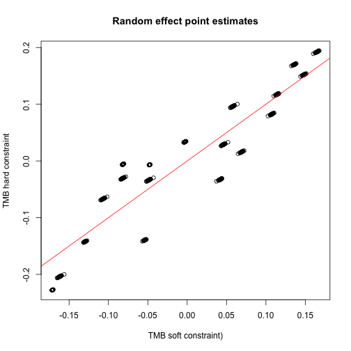

```r
plot(summary(sdr8, "report")[,1], summary(sdr8b, "report")[,1],
     xlab = "TMB soft constraint)", ylab = "TMB hard constraint",
     main = "Random effect point estimates")
abline(0, 1, col = "red")
```

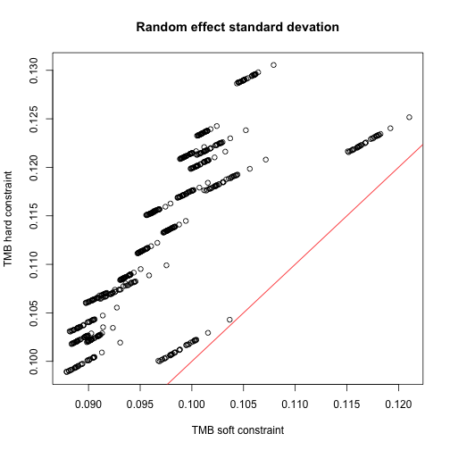

```r
plot(summary(sdr8, "report")[,2], summary(sdr8b, "report")[,2],
     xlab = "TMB soft constraint", ylab = "TMB hard constraint",
     main = "Random effect standard devation")
abline(0, 1, col = "red")
```

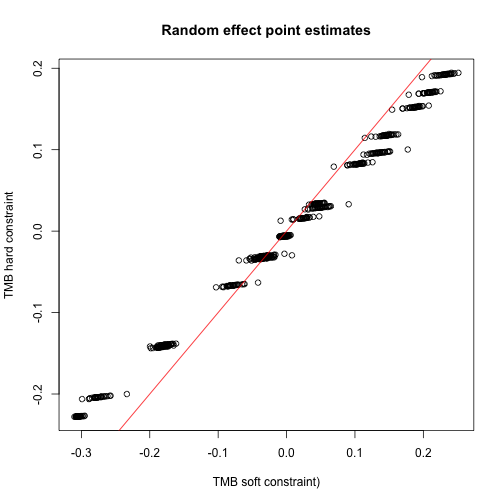

```r
plot(inlafit8C$summary.random[[1]][ , 2], summary(sdr8b, "report")[,1],
     xlab = "TMB soft constraint)", ylab = "TMB hard constraint",
     main = "Random effect point estimates")
abline(0, 1, col = "red")
```

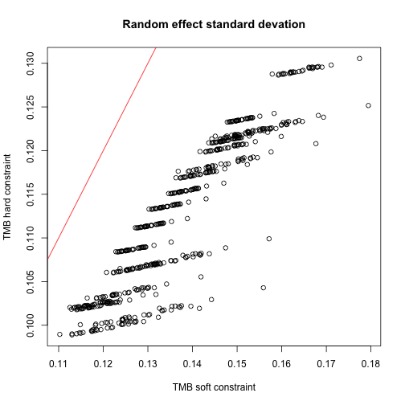

```r
plot(inlafit8C$summary.random[[1]][ , 3], summary(sdr8b, "report")[,2],
     xlab = "TMB soft constraint", ylab = "TMB hard constraint",
     main = "Random effect standard devation")
abline(0, 1, col = "red")
```

## Model 9: ICAR space x RW1 time with full constraints

```r
R_space <- diag(rowSums(adj.mat)) - adj.mat
R_space_scaled <- inla.scale.model(R_space, constr = list(A = matrix(1, ncol = ncol(R_space)), e = 0))
R_space_scaled_adj <- R_space_scaled + Matrix::Diagonal(ncol(R_space_scaled), diagval)

D_time <- diff(diag(length(levels(data$Yearf))), differences = 1)
R_time <- Matrix::Matrix(t(D_time) %*% D_time)
R_time_scaled <- inla.scale.model(R_time, constr = list(A = matrix(1, ncol = ncol(R_time)), e = 0))
R_time_scaled_adj <- R_time_scaled + Matrix::Diagonal(ncol(R_time_scaled), diagval)

R_space_time <- kronecker(R_time_scaled, R_space_scaled)

eig <- eigen(R_space_time)
eigval <- zapsmall(eig$values)
eigvec <- eig$vectors

rankdef <- nrow(R_space) + ncol(R_time) - 1

sum(eigval == 0)
```

```
## [1] 50
```

```r
rankdef
```

```
## [1] 50
```

```r
Aconstr <- t(eigvec[ , eigval == 0])

inlafit9C <- inla(Observed ~
                   f(id.area.year, model = "generic0", Cmatrix = R_space_time,
                     hyper = prec.prior, diagonal = diagval, rankdef = rankdef,
                     extraconstr = list(A = Aconstr, e = numeric(nrow(Aconstr)))),
                 data = data, E = Expected, family = "poisson",
                 control.inla = list(strategy = "gaussian", int.strategy = "eb"),
                 control.compute = list(config = TRUE))

grep(".*rank.*", inlafit9C$logfile, value = TRUE)
```

```
## [1] "                rank-deficiency is *defined* [50]"
```

```r
summary(inlafit9C)
```

```
##
## Call:
##    c("inla.core(formula = formula, family = family, contrasts = contrasts, ", " data = data, quantiles = quantiles, E = E, offset = offset, ", " scale = scale, weights = weights, Ntrials = Ntrials, strata = strata, ",
##    " lp.scale = lp.scale, link.covariates = link.covariates, verbose = verbose, ", " lincomb = lincomb, selection = selection, control.compute = control.compute, ", " control.predictor = control.predictor,
##    control.family = control.family, ", " control.inla = control.inla, control.fixed = control.fixed, ", " control.mode = control.mode, control.expert = control.expert, ", " control.hazard = control.hazard,
##    control.lincomb = control.lincomb, ", " control.update = control.update, control.lp.scale = control.lp.scale, ", " control.pardiso = control.pardiso, only.hyperparam = only.hyperparam, ", " inla.call = inla.call,
##    inla.arg = inla.arg, num.threads = num.threads, ", " blas.num.threads = blas.num.threads, keep = keep, working.directory = working.directory, ", " silent = silent, inla.mode = inla.mode, safe = FALSE, debug = debug,
##    ", " .parent.frame = .parent.frame)")
## Time used:
##     Pre = 2.73, Running = 0.459, Post = 0.0358, Total = 3.22
## Fixed effects:
##               mean    sd 0.025quant 0.5quant 0.975quant mode kld
## (Intercept) -0.003 0.029      -0.06   -0.003      0.055   NA   0
##
## Random effects:
##   Name     Model
##     id.area.year Generic0 model
##
## Model hyperparameters:
##                              mean     sd 0.025quant 0.5quant 0.975quant mode
## Precision for id.area.year 505.78 700.20      48.34   298.97    2266.09   NA
##
## Marginal log-Likelihood:  -1224.48
##  is computed
## Posterior summaries for the linear predictor and the fitted values are computed
## (Posterior marginals needs also 'control.compute=list(return.marginals.predictor=TRUE)')
```

### TMB

```r
mod <- '
#include <TMB.hpp>

template<class Type>
Type objective_function<Type>::operator() ()
{

  using namespace density;

  DATA_VECTOR(y);
  DATA_VECTOR(E);

  DATA_MATRIX(Aconstr);
  DATA_SPARSE_MATRIX(Z_space_time);
  DATA_SPARSE_MATRIX(R_time);
  DATA_SPARSE_MATRIX(R_space);

  Type val(0);

  PARAMETER(beta0);
  // beta0 ~ 1

  PARAMETER(log_prec_space_time);
  val -= dlgamma(log_prec_space_time, Type(0.001), Type(1.0 / 0.001), true);
  Type sigma_space_time(exp(-0.5 * log_prec_space_time));

  PARAMETER_ARRAY(u_raw_space_time);
  vector<Type> u_raw_space_time_v(u_raw_space_time);
  vector<Type> u_space_time(u_raw_space_time * sigma_space_time);

  val += SEPARABLE(GMRF(R_time), GMRF(R_space))(u_raw_space_time);
  val -= dnorm(Aconstr * u_raw_space_time_v, Type(0), Type(0.001) * u_raw_space_time.cols(), true).sum();  // soft sum-to-zero constraint

  vector<Type> mu(beta0 +
                  Z_space_time * u_space_time +
                  log(E));
  val -= dpois(y, exp(mu), true).sum();

  ADREPORT(u_space_time);

  return val;
}
'

dll <- tmb_compile_and_load(mod)

R_space_time_adj <- R_space_time + Matrix::Diagonal(ncol(R_space_time), 1e-6)

tmbdata <- list(y = data$Observed,
                E = data$Expected,
                Aconstr = Aconstr,
                Z_space_time = Matrix::sparse.model.matrix(~0 + IDf:Yearf, data),
                R_space = R_space_scaled_adj,
                R_time = R_time_scaled_adj)

tmbpar <- list(beta0 = 0,
               log_prec_space_time = 0,
               u_raw_space_time = array(0, c(nrow(tmbdata$R_space), nrow(tmbdata$R_time))))

obj <- TMB::MakeADFun(data = tmbdata,
                      parameters = tmbpar,
                      random = c("beta0", "u_raw_space_time"),
                      DLL = dll)
```

```
## Constructing atomic D_lgamma
## Constructing atomic D_lgamma
```

```r
tmbfit <- nlminb(obj$par, obj$fn, obj$gr)
```

```
## Constructing atomic D_lgamma
## Optimizing tape... Done
## iter: 1  value: 927.6271 mgc: 10.896 ustep: 1
## iter: 2  value: 925.9849 mgc: 45.84467 ustep: 1
## iter: 3  value: 925.9823 mgc: 1.346765 ustep: 1
## iter: 4  value: 925.9823 mgc: 0.00214771 ustep: 1
## iter: 5  value: 925.9823 mgc: 1.800997e-08 ustep: 1
## mgc: 1.077805e-12
## iter: 1  mgc: 1.077805e-12
## Matching hessian patterns... Done
## outer mgc:  43.11252
## iter: 1  value: 953.6647 mgc: 29.41514 ustep: 1
## iter: 2  value: 953.6606 mgc: 2.163198 ustep: 1
## iter: 3  value: 953.6606 mgc: 0.003541353 ustep: 1
## iter: 4  value: 953.6606 mgc: 2.08951e-08 ustep: 1
## mgc: 1.500702e-12
## iter: 1  mgc: 1.500702e-12
## outer mgc:  22.88618
## iter: 1  value: 973.395 mgc: 17.20219 ustep: 1
## iter: 2  value: 973.3944 mgc: 0.9565384 ustep: 1
## iter: 3  value: 973.3944 mgc: 0.0005404753 ustep: 1
## iter: 4  mgc: 2.610345e-10
## iter: 1  mgc: 2.610345e-10
## outer mgc:  11.2084
## iter: 1  value: 985.4908 mgc: 9.608335 ustep: 1
## iter: 2  value: 985.4907 mgc: 0.3830463 ustep: 1
## iter: 3  value: 985.4907 mgc: 8.000485e-05 ustep: 1
## iter: 4  mgc: 4.780842e-12
## iter: 1  mgc: 4.780842e-12
## outer mgc:  5.216642
## iter: 1  value: 991.943 mgc: 5.207915 ustep: 1
## iter: 2  value: 991.943 mgc: 0.1392839 ustep: 1
## iter: 3  value: 991.943 mgc: 1.099709e-05 ustep: 1
## iter: 4  mgc: 1.636129e-12
## iter: 1  mgc: 1.636129e-12
## outer mgc:  2.423697
## iter: 1  value: 995.4436 mgc: 3.020661 ustep: 1
## iter: 2  value: 995.4436 mgc: 0.05165343 ustep: 1
## iter: 3  value: 995.4436 mgc: 1.413139e-06 ustep: 1
## iter: 4  mgc: 9.413581e-13
```

[output cut: 13 more lines]

```
## iter: 1  value: 998.3997 mgc: 0.2241802 ustep: 1
## iter: 2  value: 998.3997 mgc: 0.0002470323 ustep: 1
## iter: 3  mgc: 2.660561e-11
## iter: 1  mgc: 2.660561e-11
## outer mgc:  0.01136858
## iter: 1  value: 998.4305 mgc: 0.02669975 ustep: 1
## iter: 2  value: 998.4305 mgc: 3.735969e-06 ustep: 1
## iter: 3  mgc: 1.431626e-12
## iter: 1  mgc: 1.431626e-12
## outer mgc:  0.0003109372
## iter: 1  value: 998.4314 mgc: 0.0007461367 ustep: 1
## iter: 2  mgc: 2.945527e-09
## iter: 1  mgc: 2.945527e-09
## outer mgc:  9.161032e-07
## iter: 1  mgc: 2.945527e-09
```

```r
sdr9 <- TMB::sdreport(obj)
```

```
## iter: 1  mgc: 2.945527e-09
## outer mgc:  9.161032e-07
## iter: 1  value: 998.4334 mgc: 0.00180081 ustep: 1
## iter: 2  value: 998.4334 mgc: 1.715518e-08 ustep: 1
## mgc: 1.268069e-12
## outer mgc:  0.0007474839
## iter: 1  value: 998.4293 mgc: 0.001801946 ustep: 1
## iter: 2  value: 998.4293 mgc: 1.719177e-08 ustep: 1
## mgc: 1.079969e-12
## outer mgc:  0.0007496051
## outer mgc:  0.06160107
```

```r
summary(sdr9, "all")
```

```
##                          Estimate Std. Error
## log_prec_space_time  5.574152e+00 1.15582262
## beta0               -2.680206e-03 0.02933691
## u_raw_space_time    -7.989248e-01 1.12667280
## u_raw_space_time    -1.284828e-01 1.40810788
## u_raw_space_time    -2.963552e-01 1.22621341
## u_raw_space_time     3.140558e-01 1.51628252
## u_raw_space_time     1.007087e+00 1.84148072
## u_raw_space_time     1.741425e-01 1.23505276
## u_raw_space_time    -6.047064e-01 1.59035547
## u_raw_space_time    -2.144584e-01 1.61059493
## u_raw_space_time     3.200018e-02 1.59955459
## u_raw_space_time    -2.100527e-02 1.18385901
## u_raw_space_time     3.074912e-01 1.33420038
## u_raw_space_time     5.188217e-01 2.15639796
## u_raw_space_time     2.059059e-01 1.60574482
## u_raw_space_time    -7.900866e-02 1.02435145
## u_raw_space_time    -5.893576e-01 1.59127878
## u_raw_space_time     7.109861e-02 1.62942009
## u_raw_space_time    -8.665258e-02 1.59889122
## u_raw_space_time     1.350900e-01 1.22515111
## u_raw_space_time    -1.120157e-01 1.26287737
## u_raw_space_time     2.942985e-01 1.10782530
## u_raw_space_time    -1.574810e-02 1.23579746
## u_raw_space_time     3.595275e-01 1.32014125
## u_raw_space_time    -3.854470e-01 1.15746181
## u_raw_space_time     1.658342e-01 1.63025514
## u_raw_space_time     6.811454e-02 1.08419630
## u_raw_space_time    -2.993495e-01 1.05502035
## u_raw_space_time    -1.551094e-01 1.17570402
## u_raw_space_time    -2.638146e-01 1.20950366
## u_raw_space_time     1.638048e-01 1.62557813
## u_raw_space_time    -1.291233e-01 0.99608212
## u_raw_space_time     4.954295e-01 1.64880519
## u_raw_space_time    -1.330951e-01 1.11634433
## u_raw_space_time    -8.213341e-01 1.01032154
## u_raw_space_time    -1.142814e-01 1.29270773
## u_raw_space_time    -2.767173e-01 1.12131806
## u_raw_space_time     3.127926e-01 1.39069046
## u_raw_space_time     1.019981e+00 1.68905856
```

[output cut: 447 more lines]

```
## u_raw_space_time    -9.089453e-01 1.41691683
## u_raw_space_time    -1.678465e-01 0.94835987
## u_raw_space_time     1.214573e-01 1.16368197
## u_raw_space_time     1.701110e-01 1.22381369
## u_raw_space_time    -1.692757e-01 1.21690771
## u_raw_space_time     8.597099e-02 0.91353908
## u_raw_space_time    -2.145619e-01 1.02269847
## u_raw_space_time    -5.905126e-01 1.65554192
## u_raw_space_time    -1.938868e-01 1.21895768
## u_raw_space_time     7.415618e-02 0.78762146
## u_raw_space_time     6.169956e-01 1.22463587
## u_raw_space_time    -2.597728e-01 1.23780667
## u_raw_space_time     5.169543e-02 1.21907293
## u_raw_space_time    -2.753455e-02 0.93577681
##  [ reached getOption("max.print") -- omitted 718 rows ]
```

Hyper parameter comparison

```r
summary(sdr9, "fixed")
```

```
##                     Estimate Std. Error
## log_prec_space_time 5.574152   1.155823
```

```r
cbind("mean" = inlafit9C$misc$theta.mode,
      "se" = sqrt(diag(inlafit9C$misc$cov.intern)))
```

```
##         mean       se
## [1,] 5.57856 1.157749
```

Fixed effects (Intercept)

```r
summary(sdr9, "random")[1, , drop = FALSE]
```

```
##           Estimate Std. Error
## beta0 -0.002680206 0.02933691
```

```r
inlafit9C$summary.fixed[ , 1:2]
```

```
##                     mean         sd
## (Intercept) -0.002674908 0.02926464
```

Random effects mean and standard deviation

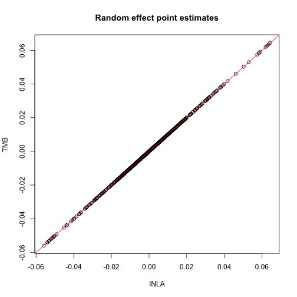

```r
plot(inlafit9C$summary.random[[1]][,2], summary(sdr9, "report")[,1],
     xlab = "INLA", ylab = "TMB", main = "Random effect point estimates")
abline(0, 1, col = "red")
```

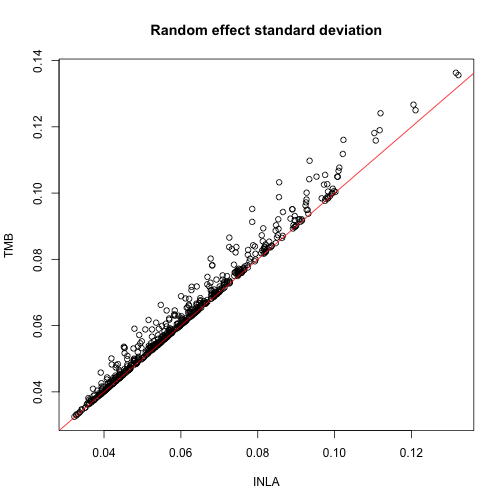

```r
plot(inlafit9C$summary.random[[1]][,3], summary(sdr9, "report")[,2],
     xlab = "INLA", ylab = "TMB", main = "Random effect standard deviation")
abline(0, 1, col = "red")
```

### Model 9b: Explicit sum-to-zero constraint

This one gets slow!

```r
mod <- '
#include <TMB.hpp>

template<class Type>
Type objective_function<Type>::operator() ()
{

  using namespace density;

  DATA_VECTOR(y);
  DATA_VECTOR(E);

  DATA_MATRIX(L_space_time)
  DATA_SPARSE_MATRIX(Z_space_time);
  DATA_SPARSE_MATRIX(LRL_space_time);

  Type val(0);

  PARAMETER(beta0);
  // beta0 ~ 1

  PARAMETER(log_prec_space_time);
  val -= dlgamma(log_prec_space_time, Type(0.001), Type(1.0 / 0.001), true);
  Type sigma_space_time(exp(-0.5 * log_prec_space_time));

  PARAMETER_VECTOR(u_raw_space_time);
  vector<Type> u_space_time(L_space_time * u_raw_space_time * sigma_space_time);

  val += GMRF(LRL_space_time)(u_raw_space_time);

  vector<Type> mu(beta0 +
                  Z_space_time * u_space_time +
                  log(E));
  val -= dpois(y, exp(mu), true).sum();

  ADREPORT(u_space_time);

  return val;
}
'

dll <- tmb_compile_and_load(mod)

qrc <- qr(t(Aconstr))
L_space_time <- qr.Q(qrc, complete=TRUE)[ , (nrow(Aconstr)+1):ncol(Aconstr)]

LRL <- as(t(L_space_time) %*% R_space_time %*% L_space_time, "dgCMatrix")
LRL_adj <- LRL + Matrix::Diagonal(ncol(LRL), diagval)

tmbdata <- list(y = data$Observed,
                E = data$Expected,
                L_space_time = L_space_time,
                Z_space_time = Matrix::sparse.model.matrix(~0 + IDf:Yearf, data),
                LRL_space_time = LRL_adj)

tmbpar <- list(beta0 = 0,
               log_prec_space_time = 0,
               u_raw_space_time = numeric(ncol(tmbdata$L_space_time)))

obj <- TMB::MakeADFun(data = tmbdata,
                      parameters = tmbpar,
                      random = c("beta0", "u_raw_space_time"),
                      DLL = dll)
```

```
## Constructing atomic D_lgamma
## Constructing atomic D_lgamma
```

```r
tmbfit <- nlminb(obj$par, obj$fn, obj$gr)
```

```
## Constructing atomic D_lgamma
## Optimizing tape... Done
## iter: 1  value: 814.737 mgc: 8.328949 ustep: 1
## iter: 2  value: 813.095 mgc: 45.85354 ustep: 1
## iter: 3  value: 813.0924 mgc: 1.347449 ustep: 1
## iter: 4  value: 813.0924 mgc: 0.002148985 ustep: 1
## iter: 5  value: 813.0924 mgc: 1.802372e-08 ustep: 1
## mgc: 1.465494e-14
## iter: 1  mgc: 1.465494e-14
## Matching hessian patterns... Done
## outer mgc:  43.16224
## iter: 1  value: 840.7554 mgc: 29.31029 ustep: 1
## iter: 2  value: 840.7513 mgc: 2.160366 ustep: 1
## iter: 3  value: 840.7513 mgc: 0.003529377 ustep: 1
## iter: 4  value: 840.7513 mgc: 2.073619e-08 ustep: 1
## mgc: 1.101341e-13
## iter: 1  mgc: 1.101341e-13
## outer mgc:  22.89969
## iter: 1  value: 860.4808 mgc: 17.16802 ustep: 1
## iter: 2  value: 860.4802 mgc: 0.9558082 ustep: 1
## iter: 3  value: 860.4802 mgc: 0.0005395115 ustep: 1
## iter: 4  mgc: 2.599752e-10
## iter: 1  mgc: 2.599752e-10
## outer mgc:  11.21185
## iter: 1  value: 872.5708 mgc: 9.592861 ustep: 1
## iter: 2  value: 872.5707 mgc: 0.3825053 ustep: 1
## iter: 3  value: 872.5707 mgc: 7.978427e-05 ustep: 1
## iter: 4  mgc: 4.760414e-12
## iter: 1  mgc: 4.760414e-12
## outer mgc:  5.21913
## iter: 1  value: 879.0239 mgc: 5.203446 ustep: 1
## iter: 2  value: 879.0239 mgc: 0.1391804 ustep: 1
## iter: 3  value: 879.0239 mgc: 1.098334e-05 ustep: 1
## iter: 4  mgc: 1.190159e-13
## iter: 1  mgc: 1.190159e-13
## outer mgc:  2.424507
## iter: 1  value: 882.5247 mgc: 3.017845 ustep: 1
## iter: 2  value: 882.5247 mgc: 0.05160695 ustep: 1
## iter: 3  value: 882.5247 mgc: 1.410715e-06 ustep: 1
## iter: 4  mgc: 2.775558e-14
```

[output cut: 13 more lines]

```
## iter: 1  value: 885.4822 mgc: 0.2244321 ustep: 1
## iter: 2  value: 885.4822 mgc: 0.0002477548 ustep: 1
## iter: 3  mgc: 2.672373e-11
## iter: 1  mgc: 2.672373e-11
## outer mgc:  0.01141877
## iter: 1  value: 885.5132 mgc: 0.02681039 ustep: 1
## iter: 2  value: 885.5132 mgc: 3.769934e-06 ustep: 1
## iter: 3  mgc: 2.420286e-14
## iter: 1  mgc: 2.420286e-14
## outer mgc:  0.000313889
## iter: 1  value: 885.514 mgc: 0.0007531025 ustep: 1
## iter: 2  mgc: 3.003192e-09
## iter: 1  mgc: 3.003192e-09
## outer mgc:  9.323871e-07
## iter: 1  mgc: 3.003192e-09
```

```r
sdr9b <- TMB::sdreport(obj)
```

```
## iter: 1  mgc: 3.003192e-09
## outer mgc:  9.323871e-07
## iter: 1  value: 885.5161 mgc: 0.001800243 ustep: 1
## iter: 2  value: 885.5161 mgc: 1.715861e-08 ustep: 1
## mgc: 1.230127e-13
## outer mgc:  0.0007473303
## iter: 1  value: 885.5119 mgc: 0.001801379 ustep: 1
## iter: 2  value: 885.5119 mgc: 1.719521e-08 ustep: 1
## mgc: 2.68674e-14
## outer mgc:  0.000749485
## outer mgc:  0.05741589
```

```r
summary(sdr9b, "all")
```

```
##                          Estimate Std. Error
## log_prec_space_time  5.572942e+00 1.15592828
## beta0               -2.679220e-03 0.02933672
## u_raw_space_time    -3.577492e-02 1.27749115
## u_raw_space_time     2.470870e-01 1.02202678
## u_raw_space_time    -1.502620e-01 1.12606194
## u_raw_space_time     2.559488e-01 1.34799904
## u_raw_space_time    -4.927598e-01 1.05082459
## u_raw_space_time     1.170255e-01 1.56641214
## u_raw_space_time     6.551324e-03 1.03973898
## u_raw_space_time    -2.475447e-01 0.93724336
## u_raw_space_time    -1.163255e-01 1.05572958
## u_raw_space_time    -1.801598e-01 1.10189275
## u_raw_space_time     5.212785e-02 1.35555608
## u_raw_space_time    -7.827538e-02 0.98749415
## u_raw_space_time     5.268476e-01 1.53767806
## u_raw_space_time    -2.529911e-01 1.03759416
## u_raw_space_time    -6.969417e-01 0.88472258
## u_raw_space_time    -1.092774e-01 1.14316860
## u_raw_space_time    -3.810248e-01 1.09490285
## u_raw_space_time     3.317466e-01 1.26159426
## u_raw_space_time     9.607264e-01 1.54668385
## u_raw_space_time     2.203972e-01 1.08023453
## u_raw_space_time    -2.486459e-01 1.26074127
## u_raw_space_time    -1.721961e-01 1.34210412
## u_raw_space_time     1.844905e-01 1.37538303
## u_raw_space_time    -5.130454e-02 0.99213795
## u_raw_space_time     2.863846e-01 0.91189864
## u_raw_space_time     5.182396e-01 1.83679630
## u_raw_space_time     1.871840e-01 1.29756814
## u_raw_space_time    -6.475683e-02 0.84829090
## u_raw_space_time    -5.692713e-01 1.37687378
## u_raw_space_time     1.987702e-01 1.25080786
## u_raw_space_time    -2.705554e-01 1.43161219
## u_raw_space_time     1.231516e-01 0.98611481
## u_raw_space_time     8.538261e-02 1.21842455
## u_raw_space_time     3.352006e-01 0.92096629
## u_raw_space_time    -1.398530e-01 1.07492483
## u_raw_space_time     3.663496e-01 1.20127992
## u_raw_space_time    -4.590269e-01 0.98537264
```

[output cut: 447 more lines]

```
## u_raw_space_time     3.297654e-01 1.06522787
## u_raw_space_time    -1.182208e-01 1.39347011
## u_raw_space_time     2.299712e-01 0.96838674
## u_raw_space_time     7.067405e-01 1.02882142
## u_raw_space_time    -3.417453e-02 1.03815973
## u_raw_space_time     3.492913e-01 1.14926103
## u_raw_space_time    -9.571218e-02 1.47924270
## u_raw_space_time     3.869439e-01 0.92552778
## u_raw_space_time    -3.584174e-01 1.45072158
## u_raw_space_time     2.589914e-01 1.03975639
## u_raw_space_time     1.208760e+00 1.12862621
## u_raw_space_time     6.287338e-02 1.40170833
## u_raw_space_time     3.735778e-01 1.16401941
## u_raw_space_time    -1.327994e-01 1.43247617
##  [ reached getOption("max.print") -- omitted 668 rows ]
```

Hyper parameter comparison

```r
summary(sdr9, "fixed")
```

```
##                     Estimate Std. Error
## log_prec_space_time 5.574152   1.155823
```

```r
summary(sdr9b, "fixed")
```

```
##                     Estimate Std. Error
## log_prec_space_time 5.572942   1.155928
```

```r
cbind("mean" = inlafit9C$misc$theta.mode,
      "se" = sqrt(diag(inlafit9C$misc$cov.intern)))
```

```
##         mean       se
## [1,] 5.57856 1.157749
```

Fixed effects (Intercept)

```r
summary(sdr9, "random")[1, , drop = FALSE]
```

```
##           Estimate Std. Error
## beta0 -0.002680206 0.02933691
```

```r
summary(sdr9b, "random")[1, , drop = FALSE]
```

```
##          Estimate Std. Error
## beta0 -0.00267922 0.02933672
```

```r
inlafit9C$summary.fixed[ , 1:2]
```

```
##                     mean         sd
## (Intercept) -0.002674908 0.02926464
```

Random effects mean and standard deviation

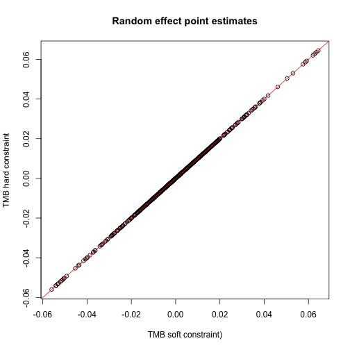

```r
plot(summary(sdr9, "report")[,1], summary(sdr9b, "report")[,1],
     xlab = "TMB soft constraint)", ylab = "TMB hard constraint",
     main = "Random effect point estimates")
abline(0, 1, col = "red")
```

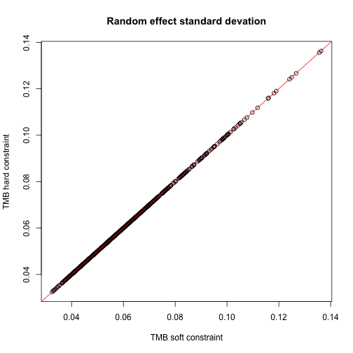

```r
plot(summary(sdr9, "report")[,2], summary(sdr9b, "report")[,2],
     xlab = "TMB soft constraint", ylab = "TMB hard constraint",
     main = "Random effect standard devation")
abline(0, 1, col = "red")
```

## Model 10: ICAR space + RW1 time + ICAR space x RW1 time

Model fit with full Type IV constraints

```r
R_space <- diag(rowSums(adj.mat)) - adj.mat
R_space_scaled <- inla.scale.model(R_space, constr = list(A = matrix(1, ncol = ncol(R_space)), e = 0))
R_space_scaled_adj <- R_space_scaled + Matrix::Diagonal(ncol(R_space_scaled), diagval)

D_time <- diff(diag(length(levels(data$Yearf))), differences = 1)
R_time <- Matrix::Matrix(t(D_time) %*% D_time)
R_time_scaled <- inla.scale.model(R_time, constr = list(A = matrix(1, ncol = ncol(R_time)), e = 0))
R_time_scaled_adj <- R_time_scaled + Matrix::Diagonal(ncol(R_time_scaled), diagval)

R_space_time <- kronecker(R_time_scaled, R_space_scaled)

eig <- eigen(R_space_time)
eigval <- zapsmall(eig$values)
eigvec <- eig$vectors

rankdef <- nrow(R_space) + ncol(R_time) - 1

sum(eigval == 0)
```

```
## [1] 50
```

```r
rankdef
```

```
## [1] 50
```

```r
Aconstr <- t(eigvec[ , eigval == 0])

inlafit10 <- inla(Observed ~
                    f(ID, model = "besag", graph = adj.mat, hyper = prec.prior,
                      diagonal = diagval, scale.model = TRUE) +
                    f(Year, model = "rw1", hyper = prec.prior,
                      diagonal = diagval, scale.model = TRUE) +
                    f(id.area.year, model = "generic0", Cmatrix = R_space_time,
                      hyper = prec.prior, diagonal = diagval, rankdef = rankdef,
                      extraconstr = list(A = Aconstr, e = numeric(nrow(Aconstr)))),
                  data = data, E = Expected, family = "poisson",
                  control.inla = list(strategy = "gaussian", int.strategy = "eb"),
                  control.compute = list(config = TRUE))

grep(".*rank.*", inlafit10$logfile, value = TRUE)
```

```
## [1] "                rank-deficiency is *defined* [1]"       "                computed/guessed rank-deficiency = [1]" "                rank-deficiency is *defined* [50]"
```

The precision parameter estimates match

```r
summary(inlafit10)
```

```
##
## Call:
##    c("inla.core(formula = formula, family = family, contrasts = contrasts, ", " data = data, quantiles = quantiles, E = E, offset = offset, ", " scale = scale, weights = weights, Ntrials = Ntrials, strata = strata, ",
##    " lp.scale = lp.scale, link.covariates = link.covariates, verbose = verbose, ", " lincomb = lincomb, selection = selection, control.compute = control.compute, ", " control.predictor = control.predictor,
##    control.family = control.family, ", " control.inla = control.inla, control.fixed = control.fixed, ", " control.mode = control.mode, control.expert = control.expert, ", " control.hazard = control.hazard,
##    control.lincomb = control.lincomb, ", " control.update = control.update, control.lp.scale = control.lp.scale, ", " control.pardiso = control.pardiso, only.hyperparam = only.hyperparam, ", " inla.call = inla.call,
##    inla.arg = inla.arg, num.threads = num.threads, ", " blas.num.threads = blas.num.threads, keep = keep, working.directory = working.directory, ", " silent = silent, inla.mode = inla.mode, safe = FALSE, debug = debug,
##    ", " .parent.frame = .parent.frame)")
## Time used:
##     Pre = 2.93, Running = 0.716, Post = 0.0275, Total = 3.67
## Fixed effects:
##               mean    sd 0.025quant 0.5quant 0.975quant mode kld
## (Intercept) -0.046 0.036     -0.118   -0.046      0.025   NA   0
##
## Random effects:
##   Name     Model
##     ID Besags ICAR model
##    Year RW1 model
##    id.area.year Generic0 model
##
## Model hyperparameters:
##                              mean     sd 0.025quant 0.5quant 0.975quant mode
## Precision for ID           141.39 143.92      22.44    99.03     521.47   NA
## Precision for Year         280.66 398.04      23.67   162.71    1273.21   NA
## Precision for id.area.year 523.67 517.68      61.08   371.04    1922.06   NA
##
## Marginal log-Likelihood:  -1247.95
##  is computed
## Posterior summaries for the linear predictor and the fitted values are computed
## (Posterior marginals needs also 'control.compute=list(return.marginals.predictor=TRUE)')
```

Hyper parameters

```r
inlafit10$internal.summary.hyperpar[, 1:2]
```

```
##                                    mean        sd
## Log precision for ID           4.622354 0.7983025
## Log precision for Year         5.111969 1.0112702
## Log precision for id.area.year 5.891910 0.8674816
```

### TMB

```r
mod <- '
#include <TMB.hpp>

template<class Type>
Type objective_function<Type>::operator() ()
{

  using namespace density;

  DATA_VECTOR(y);
  DATA_VECTOR(E);

  DATA_SPARSE_MATRIX(Z_space);
  DATA_SPARSE_MATRIX(Z_time);

  DATA_MATRIX(C_space_time);
  DATA_SPARSE_MATRIX(Z_space_time);
  DATA_SPARSE_MATRIX(R_time);
  DATA_SPARSE_MATRIX(R_space);

  Type val(0);

  PARAMETER(beta0);
  // beta0 ~ 1

  PARAMETER(log_prec_space);
  val -= dlgamma(log_prec_space, Type(0.001), Type(1.0 / 0.001), true);
  Type sigma_space(exp(-0.5 * log_prec_space));

  PARAMETER_VECTOR(u_raw_space);
  vector<Type> u_space(u_raw_space * sigma_space);

  val += GMRF(R_space)(u_raw_space);
  val -= dnorm(u_raw_space.sum(), Type(0), Type(0.001) * u_raw_space.size(), true);  // soft sum-to-zero constraint


  PARAMETER(log_prec_time);
  val -= dlgamma(log_prec_time, Type(0.001), Type(1.0 / 0.001), true);
  Type sigma_time(exp(-0.5 * log_prec_time));

  PARAMETER_VECTOR(u_raw_time);
  vector<Type> u_time(u_raw_time * sigma_time);

  val += GMRF(R_time)(u_raw_time);
  val -= dnorm(u_raw_time.sum(), Type(0), Type(0.001) * u_raw_time.size(), true);  // soft sum-to-zero constraint


  PARAMETER(log_prec_space_time);
  val -= dlgamma(log_prec_space_time, Type(0.001), Type(1.0 / 0.001), true);
  Type sigma_space_time(exp(-0.5 * log_prec_space_time));

  PARAMETER_ARRAY(u_raw_space_time);
  vector<Type> u_raw_space_time_v(u_raw_space_time);
  vector<Type> u_space_time(u_raw_space_time * sigma_space_time);

  val += SEPARABLE(GMRF(R_time), GMRF(R_space))(u_raw_space_time);
  val -= dnorm(C_space_time * u_raw_space_time_v, Type(0), Type(0.001) * u_raw_space_time.cols(), true).sum();  // soft sum-to-zero constraint

  vector<Type> mu(beta0 +
                  Z_space * u_space +
                  Z_time * u_time +
                  Z_space_time * u_space_time +
                  log(E));
  val -= dpois(y, exp(mu), true).sum();

  ADREPORT(u_space);
  ADREPORT(u_time);
  ADREPORT(u_space_time);

  return val;
}
'

dll <- tmb_compile_and_load(mod)

R_space_time_adj <- R_space_time + Matrix::Diagonal(ncol(R_space_time), 1e-6)

tmbdata <- list(y = data$Observed,
                E = data$Expected,
                Z_space = Matrix::sparse.model.matrix(~0 + IDf, data),
                Z_time = Matrix::sparse.model.matrix(~0 + Yearf, data),
                C_space_time = Aconstr,
                Z_space_time = Matrix::sparse.model.matrix(~0 + IDf:Yearf, data),
                R_space = R_space_scaled_adj,
                R_time = R_time_scaled_adj)

tmbpar <- list(beta0 = 0,
               log_prec_space = 0,
               u_raw_space = numeric(nrow(tmbdata$R_space)),
               log_prec_time = 0,
               u_raw_time = numeric(nrow(tmbdata$R_time)),
               log_prec_space_time = 0,
               u_raw_space_time = array(0, c(nrow(tmbdata$R_space), nrow(tmbdata$R_time))))

obj <- TMB::MakeADFun(data = tmbdata,
                      parameters = tmbpar,
                      random = c("beta0", "u_raw_space", "u_raw_time", "u_raw_space_time"),
                      DLL = dll)
```

```
## Constructing atomic D_lgamma
## Constructing atomic D_lgamma
```

```r
tmbfit <- nlminb(obj$par, obj$fn, obj$gr)
```

```
## Constructing atomic D_lgamma
## Optimizing tape... Done
## iter: 1  value: 952.6431 mgc: 35.62605 ustep: 1
## iter: 2  value: 947.5265 mgc: 72.95483 ustep: 1
## iter: 3  value: 947.494 mgc: 4.112867 ustep: 1
## iter: 4  value: 947.494 mgc: 0.02819515 ustep: 1
## iter: 5  value: 947.494 mgc: 3.550484e-06 ustep: 1
## iter: 6  mgc: 9.75206e-13
## iter: 1  mgc: 9.75206e-13
## Matching hessian patterns... Done
## outer mgc:  37.33479
## iter: 1  value: 973.8367 mgc: 47.83538 ustep: 1
## iter: 2  value: 973.8271 mgc: 2.954594 ustep: 1
## iter: 3  value: 973.8271 mgc: 0.00875817 ustep: 1
## iter: 4  value: 973.8271 mgc: 2.307503e-07 ustep: 1
## iter: 5  mgc: 1.010719e-12
## iter: 1  value: 998.6883 mgc: 43.68099 ustep: 1
## iter: 2  value: 998.6836 mgc: 2.223908 ustep: 1
## iter: 3  value: 998.6836 mgc: 0.004283117 ustep: 1
## iter: 4  value: 998.6836 mgc: 4.917484e-08 ustep: 1
## mgc: 1.668624e-12
## iter: 1  mgc: 1.668624e-12
## outer mgc:  10.09791
## iter: 1  value: 1017.206 mgc: 79.74195 ustep: 1
## iter: 2  value: 1017.173 mgc: 7.008863 ustep: 1
## iter: 3  value: 1017.173 mgc: 0.03066151 ustep: 1
## iter: 4  value: 1017.173 mgc: 8.307987e-07 ustep: 1
## iter: 5  mgc: 1.316558e-12
## iter: 1  mgc: 1.316558e-12
## outer mgc:  4.878327
## iter: 1  value: 1029.686 mgc: 55.1003 ustep: 1
## iter: 2  value: 1029.674 mgc: 3.874108 ustep: 1
## iter: 3  value: 1029.674 mgc: 0.0112859 ustep: 1
## iter: 4  value: 1029.674 mgc: 1.433741e-07 ustep: 1
## mgc: 1.086353e-12
## iter: 1  mgc: 1.086353e-12
## outer mgc:  2.081352
## iter: 1  value: 1034.302 mgc: 8.404285 ustep: 1
## iter: 2  value: 1034.301 mgc: 0.8125449 ustep: 1
## iter: 3  value: 1034.301 mgc: 0.0003569403 ustep: 1
```

[output cut: 30 more lines]

```
## iter: 1  value: 1037.655 mgc: 0.1306869 ustep: 1
## iter: 2  value: 1037.655 mgc: 1.684527e-05 ustep: 1
## iter: 3  mgc: 2.462919e-12
## iter: 1  mgc: 2.462919e-12
## outer mgc:  0.0004569651
## iter: 1  value: 1037.654 mgc: 0.004918911 ustep: 1
## iter: 2  value: 1037.654 mgc: 9.291199e-08 ustep: 1
## mgc: 1.847245e-12
## iter: 1  mgc: 1.847245e-12
## outer mgc:  7.778353e-05
## iter: 1  value: 1037.654 mgc: 0.0003951192 ustep: 1
## iter: 2  mgc: 1.796812e-09
## iter: 1  mgc: 1.796812e-09
## outer mgc:  8.443912e-06
## iter: 1  mgc: 1.796812e-09
```

```r
sdr10 <- TMB::sdreport(obj)
```

```
## iter: 1  mgc: 1.796812e-09
## outer mgc:  8.443912e-06
## iter: 1  value: 1037.657 mgc: 0.02371041 ustep: 1
## iter: 2  value: 1037.657 mgc: 5.749909e-07 ustep: 1
## mgc: 9.873768e-13
## outer mgc:  0.001309724
## iter: 1  value: 1037.651 mgc: 0.02372476 ustep: 1
## iter: 2  value: 1037.651 mgc: 5.760215e-07 ustep: 1
## mgc: 1.232348e-12
## outer mgc:  0.00130711
## iter: 1  value: 1037.655 mgc: 0.006838659 ustep: 1
## iter: 2  value: 1037.655 mgc: 2.790028e-07 ustep: 1
## mgc: 4.307332e-12
## outer mgc:  0.0008380749
## iter: 1  value: 1037.652 mgc: 0.006843412 ustep: 1
## iter: 2  value: 1037.652 mgc: 2.795464e-07 ustep: 1
## mgc: 3.075762e-12
## outer mgc:  0.0008551367
## iter: 1  value: 1037.655 mgc: 0.0003761921 ustep: 1
## iter: 2  mgc: 7.452518e-09
## outer mgc:  0.000745779
## iter: 1  value: 1037.652 mgc: 0.0003764072 ustep: 1
## iter: 2  mgc: 7.470475e-09
## outer mgc:  0.0007596984
## outer mgc:  0.107688
```

```r
sdr10sum <- summary(sdr10, "all")
```

Hyper parameter comparison

```r
summary(sdr10, "fixed")
```

```
##                     Estimate Std. Error
## log_prec_space      4.457034   0.874251
## log_prec_time       5.020457   1.086855
## log_prec_space_time 6.012000   1.152610
```

```r
cbind("mean" = inlafit10$misc$theta.mode,
      "se" = sqrt(diag(inlafit10$misc$cov.intern)))
```

```
##          mean        se
## [1,] 4.489782 0.9050627
## [2,] 5.014911 1.0366458
## [3,] 6.014394 1.4702940
```

Fixed effects (Intercept)

```r
summary(sdr10, "random")[1, , drop = FALSE]
```

```
##          Estimate Std. Error
## beta0 -0.04673713 0.03797077
```

```r
inlafit10$summary.fixed[ , 1:2]
```

```
##                    mean         sd
## (Intercept) -0.04637902 0.03647182
```

Random effects mean and standard deviation

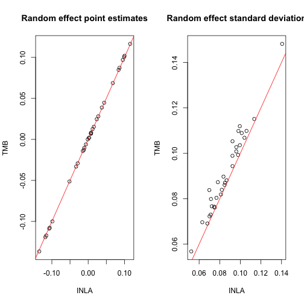

```r
par(mfrow = c(1, 2))

plot(inlafit10$summary.random[[1]][,2],
     sdr10sum[rownames(sdr10sum) == "u_space", 1],
     xlab = "INLA", ylab = "TMB", main = "Random effect point estimates")
abline(0, 1, col = "red")

plot(inlafit10$summary.random[[1]][,3],
     sdr10sum[rownames(sdr10sum) == "u_space", 2],
     xlab = "INLA", ylab = "TMB", main = "Random effect standard deviation")
abline(0, 1, col = "red")
```

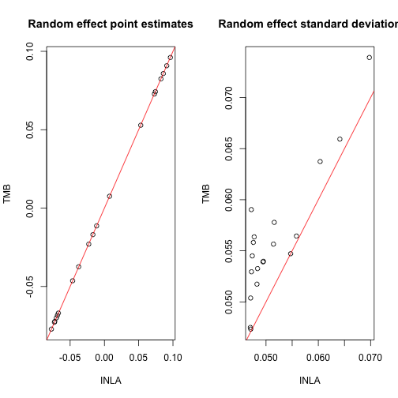

```r
plot(inlafit10$summary.random[[2]][,2],
     sdr10sum[rownames(sdr10sum) == "u_time", 1],
     xlab = "INLA", ylab = "TMB", main = "Random effect point estimates")
abline(0, 1, col = "red")

plot(inlafit10$summary.random[[2]][,3],
     sdr10sum[rownames(sdr10sum) == "u_time", 2],
     xlab = "INLA", ylab = "TMB", main = "Random effect standard deviation")
abline(0, 1, col = "red")
```

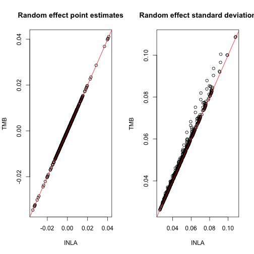

```r
plot(inlafit10$summary.random[[3]][,2],
     sdr10sum[rownames(sdr10sum) == "u_space_time", 1],
     xlab = "INLA", ylab = "TMB", main = "Random effect point estimates")
abline(0, 1, col = "red")

plot(inlafit10$summary.random[[3]][,3],
     sdr10sum[rownames(sdr10sum) == "u_space_time", 2],
     xlab = "INLA", ylab = "TMB", main = "Random effect standard deviation")
abline(0, 1, col = "red")
```

## Model 11: AR1 time

```r
inlafit11 <- inla(Observed ~
                    f(Year, model = "ar1", hyper = c(prec.prior, rho.prior)),
                  data = data, E = Expected, family = "poisson",
                  control.inla = list(strategy = "gaussian", int.strategy = "eb"),
                  control.compute = list(config = TRUE))

grep(".*rank.*", inlafit11$logfile, value = TRUE)
```

```
## [1] "                computed/guessed rank-deficiency = [0]"
```

```r
summary(inlafit11)
```

```
##
## Call:
##    c("inla.core(formula = formula, family = family, contrasts = contrasts, ", " data = data, quantiles = quantiles, E = E, offset = offset, ", " scale = scale, weights = weights, Ntrials = Ntrials, strata = strata, ",
##    " lp.scale = lp.scale, link.covariates = link.covariates, verbose = verbose, ", " lincomb = lincomb, selection = selection, control.compute = control.compute, ", " control.predictor = control.predictor,
##    control.family = control.family, ", " control.inla = control.inla, control.fixed = control.fixed, ", " control.mode = control.mode, control.expert = control.expert, ", " control.hazard = control.hazard,
##    control.lincomb = control.lincomb, ", " control.update = control.update, control.lp.scale = control.lp.scale, ", " control.pardiso = control.pardiso, only.hyperparam = only.hyperparam, ", " inla.call = inla.call,
##    inla.arg = inla.arg, num.threads = num.threads, ", " blas.num.threads = blas.num.threads, keep = keep, working.directory = working.directory, ", " silent = silent, inla.mode = inla.mode, safe = FALSE, debug = debug,
##    ", " .parent.frame = .parent.frame)")
## Time used:
##     Pre = 3.06, Running = 0.232, Post = 0.0158, Total = 3.31
## Fixed effects:
##              mean    sd 0.025quant 0.5quant 0.975quant mode kld
## (Intercept) 0.003 0.065     -0.124    0.003      0.129   NA   0
##
## Random effects:
##   Name     Model
##     Year AR1 model
##
## Model hyperparameters:
##                       mean      sd 0.025quant 0.5quant 0.975quant mode
## Precision for Year 220.585 379.718      13.48  112.164   1107.316   NA
## Rho for Year         0.672   0.365      -0.37    0.814      0.993   NA
##
## Marginal log-Likelihood:  -799.75
##  is computed
## Posterior summaries for the linear predictor and the fitted values are computed
## (Posterior marginals needs also 'control.compute=list(return.marginals.predictor=TRUE)')
```

Hyper parameters

```r
inlafit11$internal.summary.hyperpar[, 1:2]
```

```
##                            mean       sd
## Log precision for Year 4.745884 1.120262
## Rho_intern for Year    2.314799 1.617488
```

### TMB

```r
mod <- '
#include <TMB.hpp>

template<class Type>
Type objective_function<Type>::operator() ()
{

  using namespace density;

  DATA_VECTOR(y);
  DATA_VECTOR(E);

  DATA_SPARSE_MATRIX(Z_time);

  Type val(0);

  PARAMETER(beta0);
  // beta0 ~ 1

  PARAMETER(log_prec_time);
  val -= dlgamma(log_prec_time, Type(0.001), Type(1.0 / 0.001), true);
  Type sigma_time(exp(-0.5 * log_prec_time));

  PARAMETER(logit_rho_time);
  val -= dnorm(logit_rho_time, Type(0.0), Type(1.0 / sqrt(0.15)), true);
  Type rho_time(2 * exp(logit_rho_time)/(1 + exp(logit_rho_time)) - 1);

  PARAMETER_VECTOR(u_raw_time);
  vector<Type> u_time(u_raw_time * sigma_time);

  val += AR1(rho_time)(u_raw_time);

  vector<Type> mu(beta0 +
                  Z_time * u_time +
                  log(E));
  val -= dpois(y, exp(mu), true).sum();

  ADREPORT(u_time);

  return val;
}
'

dll <- tmb_compile_and_load(mod)

tmbdata <- list(y = data$Observed,
                E = data$Expected,
                Z_time = Matrix::sparse.model.matrix(~0 + Yearf, data))

tmbpar <- list(beta0 = 0,
               log_prec_time = 0,
               logit_rho_time = 0,
               u_raw_time = numeric(ncol(tmbdata$Z_time)))

obj <- TMB::MakeADFun(data = tmbdata,
                      parameters = tmbpar,
                      random = c("beta0", "u_raw_time"),
                      DLL = dll)
```

```
## Constructing atomic D_lgamma
## Constructing atomic D_lgamma
```

```r
tmbfit <- nlminb(obj$par, obj$fn, obj$gr)
```

```
## Constructing atomic D_lgamma
## Optimizing tape... Done
## iter: 1  value: 805.5777 mgc: 17.20156 ustep: 1
## iter: 2  value: 805.4336 mgc: 12.19387 ustep: 1
## iter: 3  value: 805.4336 mgc: 0.1398173 ustep: 1
## iter: 4  value: 805.4336 mgc: 3.557602e-05 ustep: 1
## iter: 5  mgc: 5.275114e-12
## iter: 1  mgc: 5.275114e-12
## Matching hessian patterns... Done
## outer mgc:  8.635636
## iter: 1  value: 805.7733 mgc: 11.60871 ustep: 1
## iter: 2  value: 805.7707 mgc: 1.704467 ustep: 1
## iter: 3  value: 805.7707 mgc: 0.002537796 ustep: 1
## iter: 4  mgc: 8.58428e-09
## iter: 1  value: 811.1162 mgc: 18.10274 ustep: 1
## iter: 2  value: 811.1145 mgc: 1.532996 ustep: 1
## iter: 3  value: 811.1145 mgc: 0.001375118 ustep: 1
## iter: 4  mgc: 1.206562e-09
## iter: 1  mgc: 1.206562e-09
## outer mgc:  1.499919
## iter: 1  value: 811.7901 mgc: 3.946524 ustep: 1
## iter: 2  value: 811.7901 mgc: 0.256254 ustep: 1
## iter: 3  value: 811.7901 mgc: 3.015709e-05 ustep: 1
## iter: 4  mgc: 3.255174e-13
## iter: 1  mgc: 3.255174e-13
## outer mgc:  0.5081805
## iter: 1  value: 808.4816 mgc: 0.9228799 ustep: 1
## iter: 2  value: 808.4816 mgc: 0.09331421 ustep: 1
## iter: 3  value: 808.4816 mgc: 3.808991e-06 ustep: 1
## iter: 4  mgc: 3.785861e-14
## iter: 1  mgc: 3.785861e-14
## outer mgc:  0.2830488
## iter: 1  value: 805.7669 mgc: 0.4428651 ustep: 1
## iter: 2  value: 805.7669 mgc: 0.01168729 ustep: 1
## iter: 3  value: 805.7669 mgc: 6.177209e-08 ustep: 1
## mgc: 1.287859e-14
## iter: 1  mgc: 1.287859e-14
## outer mgc:  0.2569226
## iter: 1  value: 805.691 mgc: 0.1156107 ustep: 1
## iter: 2  value: 805.691 mgc: 0.002372111 ustep: 1
```

[output cut: 8 more lines]

```
## iter: 1  value: 805.3833 mgc: 0.007961357 ustep: 1
## iter: 2  value: 805.3833 mgc: 5.009115e-06 ustep: 1
## iter: 3  mgc: 8.11573e-14
## iter: 1  mgc: 8.11573e-14
## outer mgc:  0.0007937495
## iter: 1  value: 805.3743 mgc: 0.001335343 ustep: 1
## iter: 2  value: 805.3743 mgc: 1.675016e-07 ustep: 1
## mgc: 2.764455e-14
## iter: 1  mgc: 2.764455e-14
## outer mgc:  2.04878e-05
## iter: 1  value: 805.3742 mgc: 9.368344e-06 ustep: 1
## iter: 2  mgc: 5.444167e-11
## iter: 1  mgc: 5.444167e-11
## outer mgc:  6.227351e-07
## iter: 1  mgc: 5.444167e-11
```

```r
sdr11 <- TMB::sdreport(obj)
```

```
## iter: 1  mgc: 5.444167e-11
## outer mgc:  6.227351e-07
## iter: 1  value: 805.3761 mgc: 0.0005985631 ustep: 1
## iter: 2  value: 805.3761 mgc: 1.111719e-07 ustep: 1
## mgc: 3.519407e-14
## outer mgc:  0.001155428
## iter: 1  value: 805.3723 mgc: 0.000599072 ustep: 1
## iter: 2  value: 805.3723 mgc: 1.11542e-07 ustep: 1
## mgc: 7.327472e-14
## outer mgc:  0.001154648
## iter: 1  value: 805.3682 mgc: 0.001100236 ustep: 1
## iter: 2  value: 805.3682 mgc: 9.725643e-08 ustep: 1
## mgc: 2.631229e-14
## outer mgc:  0.000665116
## iter: 1  value: 805.3802 mgc: 0.001099142 ustep: 1
## iter: 2  value: 805.3802 mgc: 9.726441e-08 ustep: 1
## mgc: 6.206147e-14
## outer mgc:  0.0006646317
## outer mgc:  0.09933364
```

```r
sdr11sum <- summary(sdr11, "all")
```

Hyper parameter comparison

```r
summary(sdr11, "fixed")
```

```
##                Estimate Std. Error
## log_prec_time  4.618542   1.016693
## logit_rho_time 2.130039   1.340042
```

```r
cbind("mean" = inlafit11$misc$theta.mode,
      "se" = sqrt(diag(inlafit11$misc$cov.intern)))
```

```
##          mean       se
## [1,] 4.620572 1.024576
## [2,] 2.130285 1.331142
```

Fixed effects (Intercept)

```r
summary(sdr11, "random")[1, , drop = FALSE]
```

```
##          Estimate Std. Error
## beta0 0.002596854 0.06547004
```

```r
inlafit11$summary.fixed[ , 1:2]
```

```
##                    mean         sd
## (Intercept) 0.002593219 0.06452695
```

Random effects mean and standard deviation

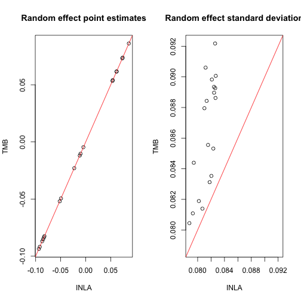

```r
par(mfrow = c(1, 2))

plot(inlafit11$summary.random[[1]][,2],
     sdr11sum[rownames(sdr11sum) == "u_time", 1],
     xlab = "INLA", ylab = "TMB", main = "Random effect point estimates")
abline(0, 1, col = "red")

x <- inlafit11$summary.random[[1]][,3]
y <- sdr11sum[rownames(sdr11sum) == "u_time", 2]
plot(x, y,
     xlab = "INLA", ylab = "TMB", main = "Random effect standard deviation",
     xlim = range(c(x, y)), ylim = range(c(x, y)))
abline(0, 1, col = "red")
```

## Model 12: IID space x AR1 time

```r
inlafit12 <- inla(Observed ~
                    f(ID, model = "iid", hyper = prec.prior,
                      group = ID.Year, control.group = list(model = "ar1", hyper = rho.prior)),
                  data = data, E = Expected, family = "poisson",
                  control.inla = list(strategy = "gaussian", int.strategy = "eb"),
                  control.compute = list(config = TRUE))

grep(".*rank.*", inlafit12$logfile, value = TRUE)
```

```
## [1] "                computed/guessed rank-deficiency = [0]"
```

```r
summary(inlafit12)
```

```
##
## Call:
##    c("inla.core(formula = formula, family = family, contrasts = contrasts, ", " data = data, quantiles = quantiles, E = E, offset = offset, ", " scale = scale, weights = weights, Ntrials = Ntrials, strata = strata, ",
##    " lp.scale = lp.scale, link.covariates = link.covariates, verbose = verbose, ", " lincomb = lincomb, selection = selection, control.compute = control.compute, ", " control.predictor = control.predictor,
##    control.family = control.family, ", " control.inla = control.inla, control.fixed = control.fixed, ", " control.mode = control.mode, control.expert = control.expert, ", " control.hazard = control.hazard,
##    control.lincomb = control.lincomb, ", " control.update = control.update, control.lp.scale = control.lp.scale, ", " control.pardiso = control.pardiso, only.hyperparam = only.hyperparam, ", " inla.call = inla.call,
##    inla.arg = inla.arg, num.threads = num.threads, ", " blas.num.threads = blas.num.threads, keep = keep, working.directory = working.directory, ", " silent = silent, inla.mode = inla.mode, safe = FALSE, debug = debug,
##    ", " .parent.frame = .parent.frame)")
## Time used:
##     Pre = 2.7, Running = 0.281, Post = 0.0451, Total = 3.03
## Fixed effects:
##               mean   sd 0.025quant 0.5quant 0.975quant mode kld
## (Intercept) -0.035 0.04     -0.113   -0.035      0.043   NA   0
##
## Random effects:
##   Name     Model
##     ID IID model
##
## Model hyperparameters:
##                    mean      sd 0.025quant 0.5quant 0.975quant mode
## Precision for ID 98.214 121.702     16.553   62.138    404.367   NA
## GroupRho for ID   0.797   0.244      0.075    0.889      0.995   NA
##
## Marginal log-Likelihood:  -799.74
##  is computed
## Posterior summaries for the linear predictor and the fitted values are computed
## (Posterior marginals needs also 'control.compute=list(return.marginals.predictor=TRUE)')
```

Hyper parameters

```r
inlafit12$internal.summary.hyperpar[, 1:2]
```

```
##                             mean        sd
## Log precision for ID    4.211307 0.8205645
## Group rho_intern for ID 2.899163 1.4805139
```

### TMB

```r
mod <- '
#include <TMB.hpp>

template<class Type>
Type objective_function<Type>::operator() ()
{

  using namespace density;

  DATA_VECTOR(y);
  DATA_VECTOR(E);

  DATA_SPARSE_MATRIX(Z_space_time);
  DATA_SPARSE_MATRIX(R_space);

  Type val(0);

  PARAMETER(beta0);
  // beta0 ~ 1

  PARAMETER(log_prec_space_time);
  val -= dlgamma(log_prec_space_time, Type(0.001), Type(1.0 / 0.001), true);
  Type sigma_space_time(exp(-0.5 * log_prec_space_time));

  PARAMETER(logit_rho_time);
  val -= dnorm(logit_rho_time, Type(0.0), Type(1.0 / sqrt(0.15)), true);
  Type rho_time(2 * exp(logit_rho_time)/(1 + exp(logit_rho_time)) - 1);

  PARAMETER_ARRAY(u_raw_space_time);
  vector<Type> u_space_time(u_raw_space_time * sigma_space_time);

  val += SEPARABLE(AR1(rho_time), GMRF(R_space))(u_raw_space_time);

  vector<Type> mu(beta0 +
                  Z_space_time * u_space_time +
                  log(E));
  val -= dpois(y, exp(mu), true).sum();

  ADREPORT(u_space_time);

  return val;
}
'

dll <- tmb_compile_and_load(mod)

n_space <- length(levels(data$IDf))
n_time <- length(levels(data$Yearf))
R_space <- Matrix::sparseMatrix(1:n_space, 1:n_space, x = rep(1L, n_space))

tmbdata <- list(y = data$Observed,
                E = data$Expected,
                Z_space_time = Matrix::sparse.model.matrix(~0 + IDf:Yearf, data),
                R_space = R_space)

tmbpar <- list(beta0 = 0,
               log_prec_space_time = 0,
               logit_rho_time = 0,
               u_raw_space_time = array(0, c(n_space, n_time)))

obj <- TMB::MakeADFun(data = tmbdata,
                      parameters = tmbpar,
                      random = c("beta0", "u_raw_space_time"),
                      DLL = dll)
```

```
## Constructing atomic D_lgamma
## Constructing atomic D_lgamma
```

```r
tmbfit <- nlminb(obj$par, obj$fn, obj$gr)
```

```
## Constructing atomic D_lgamma
## Optimizing tape... Done
## iter: 1  value: 1221.637 mgc: 10.896 ustep: 1
## iter: 2  value: 1207.961 mgc: 113.5383 ustep: 1
## iter: 3  value: 1207.651 mgc: 10.28174 ustep: 1
## iter: 4  value: 1207.65 mgc: 0.2525334 ustep: 1
## iter: 5  value: 1207.65 mgc: 0.0006668914 ustep: 1
## iter: 6  value: 1207.65 mgc: 1.314749e-08 ustep: 1
## mgc: 5.626055e-14
## iter: 1  mgc: 5.626055e-14
## Matching hessian patterns... Done
## outer mgc:  75.71355
## iter: 1  value: 1263.69 mgc: 93.50424 ustep: 1
## iter: 2  value: 1263.658 mgc: 6.104285 ustep: 1
## iter: 3  value: 1263.658 mgc: 0.02803284 ustep: 1
## iter: 4  value: 1263.658 mgc: 1.571441e-06 ustep: 1
## iter: 5  mgc: 1.229017e-13
## iter: 1  mgc: 1.229017e-13
## outer mgc:  33.81598
## iter: 1  value: 1273.149 mgc: 41.10701 ustep: 1
## iter: 2  value: 1273.144 mgc: 2.640488 ustep: 1
## iter: 3  value: 1273.144 mgc: 0.004073752 ustep: 1
## iter: 4  value: 1273.144 mgc: 1.399843e-08 ustep: 1
## mgc: 8.371082e-14
## iter: 1  mgc: 8.371082e-14
## outer mgc:  13.9721
## iter: 1  value: 1171.77 mgc: 17.60588 ustep: 1
## iter: 2  value: 1171.768 mgc: 1.844511 ustep: 1
## iter: 3  value: 1171.768 mgc: 0.001847404 ustep: 1
## iter: 4  mgc: 2.116228e-09
## iter: 1  mgc: 2.116228e-09
## outer mgc:  7.156495
## iter: 1  value: 1043.805 mgc: 15.83175 ustep: 1
## iter: 2  value: 1043.804 mgc: 0.8112685 ustep: 1
## iter: 3  value: 1043.804 mgc: 0.0003382446 ustep: 1
## iter: 4  mgc: 6.841294e-11
## iter: 1  mgc: 6.841294e-11
## outer mgc:  3.240592
## iter: 1  value: 1061.198 mgc: 11.55865 ustep: 1
## iter: 2  value: 1061.198 mgc: 0.1128681 ustep: 1
```

[output cut: 33 more lines]

```
## iter: 2  value: 962.8163 mgc: 1.487327e-05 ustep: 1
## iter: 3  mgc: 2.171596e-13
## iter: 1  mgc: 2.171596e-13
## outer mgc:  0.001916488
## iter: 1  value: 962.8566 mgc: 0.02301989 ustep: 1
## iter: 2  value: 962.8566 mgc: 4.652781e-07 ustep: 1
## iter: 3  mgc: 2.975398e-14
## iter: 1  mgc: 2.975398e-14
## outer mgc:  0.0001776109
## iter: 1  value: 962.9096 mgc: 0.003070791 ustep: 1
## iter: 2  value: 962.9096 mgc: 2.578027e-08 ustep: 1
## mgc: 4.407585e-14
## iter: 1  mgc: 4.407585e-14
## outer mgc:  9.499212e-06
## iter: 1  mgc: 4.407585e-14
```

```r
sdr12 <- TMB::sdreport(obj)
```

```
## iter: 1  mgc: 4.407585e-14
## outer mgc:  9.499212e-06
## iter: 1  value: 962.9182 mgc: 0.02243229 ustep: 1
## iter: 2  value: 962.9182 mgc: 4.227402e-07 ustep: 1
## iter: 3  mgc: 2.04281e-14
## outer mgc:  0.001745801
## iter: 1  value: 962.901 mgc: 0.02244572 ustep: 1
## iter: 2  value: 962.901 mgc: 4.234315e-07 ustep: 1
## iter: 3  mgc: 4.82947e-14
## outer mgc:  0.001752199
## iter: 1  value: 962.6637 mgc: 0.001198278 ustep: 1
## iter: 2  value: 962.6637 mgc: 3.489148e-07 ustep: 1
## iter: 3  mgc: 6.805667e-14
## outer mgc:  0.0005230835
## iter: 1  value: 963.1555 mgc: 0.001197211 ustep: 1
## iter: 2  value: 963.1555 mgc: 3.490724e-07 ustep: 1
## iter: 3  mgc: 4.551914e-14
## outer mgc:  0.0005044103
## outer mgc:  0.1506891
```

```r
sdr12sum <- summary(sdr12, "all")
```

Hyper parameter comparison

```r
summary(sdr12, "fixed")
```

```
##                     Estimate Std. Error
## log_prec_space_time 3.785073   0.789077
## logit_rho_time      2.575710   1.455927
```

```r
cbind("mean" = inlafit12$misc$theta.mode,
      "se" = sqrt(diag(inlafit12$misc$cov.intern)))
```

```
##          mean        se
## [1,] 3.794426 0.7725143
## [2,] 2.556174 1.4372996
```

Fixed effects (Intercept)

```r
summary(sdr12, "random")[1, , drop = FALSE]
```

```
##          Estimate Std. Error
## beta0 -0.03514655 0.04185747
```

```r
inlafit12$summary.fixed[ , 1:2]
```

```
##                    mean        sd
## (Intercept) -0.03488852 0.0398928
```

Random effects mean and standard deviation

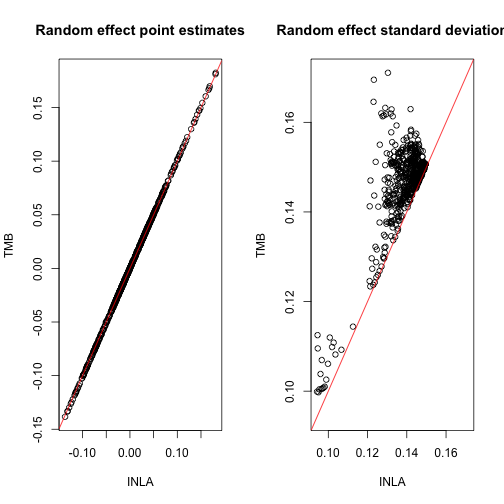

```r
par(mfrow = c(1, 2))

plot(inlafit12$summary.random[[1]][,2],
     sdr12sum[rownames(sdr12sum) == "u_space_time", 1],
     xlab = "INLA", ylab = "TMB", main = "Random effect point estimates")
abline(0, 1, col = "red")

x <- inlafit12$summary.random[[1]][,3]
y <- sdr12sum[rownames(sdr12sum) == "u_space_time", 2]
plot(x, y,
     xlab = "INLA", ylab = "TMB", main = "Random effect standard deviation",
     xlim = range(c(x, y)), ylim = range(c(x, y)))
abline(0, 1, col = "red")
```

## Model 13: ICAR space x AR1 time

This has row constraints on the interaction

```r
inlafit13 <- inla(Observed ~
                    f(ID, model = "besag", graph = adj.mat,
                      scale.model = TRUE, hyper = prec.prior,
                      group = ID.Year, control.group = list(model = "ar1", hyper = rho.prior)),
                  data = data, E = Expected, family = "poisson",
                  control.inla = list(strategy = "gaussian", int.strategy = "eb"),
                  control.compute = list(config = TRUE))

grep(".*rank.*", inlafit13$logfile, value = TRUE)
```

```
## [1] "                rank-deficiency is *defined* [1]"
```

```r
summary(inlafit13)
```

```
##
## Call:
##    c("inla.core(formula = formula, family = family, contrasts = contrasts, ", " data = data, quantiles = quantiles, E = E, offset = offset, ", " scale = scale, weights = weights, Ntrials = Ntrials, strata = strata, ",
##    " lp.scale = lp.scale, link.covariates = link.covariates, verbose = verbose, ", " lincomb = lincomb, selection = selection, control.compute = control.compute, ", " control.predictor = control.predictor,
##    control.family = control.family, ", " control.inla = control.inla, control.fixed = control.fixed, ", " control.mode = control.mode, control.expert = control.expert, ", " control.hazard = control.hazard,
##    control.lincomb = control.lincomb, ", " control.update = control.update, control.lp.scale = control.lp.scale, ", " control.pardiso = control.pardiso, only.hyperparam = only.hyperparam, ", " inla.call = inla.call,
##    inla.arg = inla.arg, num.threads = num.threads, ", " blas.num.threads = blas.num.threads, keep = keep, working.directory = working.directory, ", " silent = silent, inla.mode = inla.mode, safe = FALSE, debug = debug,
##    ", " .parent.frame = .parent.frame)")
## Time used:
##     Pre = 2.73, Running = 0.469, Post = 0.0235, Total = 3.23
## Fixed effects:
##               mean    sd 0.025quant 0.5quant 0.975quant mode kld
## (Intercept) -0.033 0.035     -0.101   -0.033      0.035   NA   0
##
## Random effects:
##   Name     Model
##     ID Besags ICAR model
##
## Model hyperparameters:
##                     mean      sd 0.025quant 0.5quant 0.975quant mode
## Precision for ID 137.693 159.074      21.69   90.361    546.657   NA
## GroupRho for ID    0.823   0.224       0.15    0.907      0.996   NA
##
## Marginal log-Likelihood:  -888.62
##  is computed
## Posterior summaries for the linear predictor and the fitted values are computed
## (Posterior marginals needs also 'control.compute=list(return.marginals.predictor=TRUE)')
```

Hyper parameters

```r
inlafit13$internal.summary.hyperpar[, 1:2]
```

```
##                             mean        sd
## Log precision for ID    4.559869 0.8234821
## Group rho_intern for ID 3.079501 1.4785585
```

Constraints

```r
nrow(inlafit13$misc$configs$constr$A)
```

```
## [1] 19
```

### TMB

The precision matrix for the ICAR x AR1 interacation is expressed as \(Q = Q_{time} \otimes Q_{space}\). `SEPARABLE` calculates the density assuming both are full rank. To apply the correct density we need to adjust the log posterior for the rank deficiency of the ICAR precision matrix.

The log determinant of the Kronecker product is \(\log |Q| = n_{time} \cdot \log |Q_{space}| + n_{space} \cdot \log |Q_{time}|\).

The log determinant adjusted for rank deficiency is \(\log |Q| = n_{time} \cdot \log |Q_{space}| + (n_{space} - k_{space}) \cdot \log |Q_{time}|\). where \(k_{space}\) is the rank deficiency \(Q_{space}\). Thus we need to subtract \(0.5 \cdot k_space \cdot \log |Q_{time}|\) to the log posterior.

For and AR1(\rho) time componenent, \(|Q^{-1}_{time}| = (1-\rho^2) ^ (n_{time} - 1)\).

```r
mod <- '
#include <TMB.hpp>

template<class Type>
Type objective_function<Type>::operator() ()
{

  using namespace density;

  DATA_VECTOR(y);
  DATA_VECTOR(E);

  DATA_SPARSE_MATRIX(Z_space_time);
  DATA_SPARSE_MATRIX(R_space);
  DATA_SCALAR(rankdef_R_space);

  Type val(0);

  PARAMETER(beta0);
  // beta0 ~ 1

  PARAMETER(log_prec_space_time);
  val -= dlgamma(log_prec_space_time, Type(0.001), Type(1.0 / 0.001), true);
  Type sigma_space_time(exp(-0.5 * log_prec_space_time));

  PARAMETER(logit_rho_time);
  val -= dnorm(logit_rho_time, Type(0.0), Type(1.0 / sqrt(0.15)), true);
  Type rho_time(2 * exp(logit_rho_time)/(1 + exp(logit_rho_time)) - 1);

  PARAMETER_ARRAY(u_raw_space_time);
  vector<Type> u_space_time(u_raw_space_time * sigma_space_time);

  val += SEPARABLE(AR1(rho_time), GMRF(R_space))(u_raw_space_time);

  // Adjust normalising constant for rank deficience of R_space
  Type log_det_Qar1((u_raw_space_time.cols() - 1) * log(1 - rho_time * rho_time));
  val -= rankdef_R_space * 0.5 * (log_det_Qar1 - log(2 * PI));

  for (int i = 0; i < u_raw_space_time.cols(); i++) {
     val -= dnorm(u_raw_space_time.col(i).sum(), Type(0), Type(0.001) * u_raw_space_time.rows(), true);
  }

  vector<Type> mu(beta0 +
                  Z_space_time * u_space_time +
                  log(E));
  val -= dpois(y, exp(mu), true).sum();

  ADREPORT(u_space_time);

  return val;
}
'

dll <- tmb_compile_and_load(mod)

n_space <- length(levels(data$IDf))
n_time <- length(levels(data$Yearf))

R_space <- diag(rowSums(adj.mat)) - adj.mat
R_space_scaled <- inla.scale.model(R_space, constr = list(A = matrix(1, ncol = ncol(R_space)), e = 0))
R_space_scaled_adj <- R_space_scaled + Matrix::Diagonal(ncol(R_space_scaled), diagval)


tmbdata <- list(y = data$Observed,
                E = data$Expected,
                Z_space_time = Matrix::sparse.model.matrix(~0 + IDf:Yearf, data),
                R_space = R_space_scaled_adj,
                rankdef_R_space = nrow(R_space_scaled) - as.integer(rankMatrix(R_space_scaled)))

tmbpar <- list(beta0 = 0,
               log_prec_space_time = 0,
               logit_rho_time = 2,
               u_raw_space_time = array(0, c(n_space, n_time)))

obj <- TMB::MakeADFun(data = tmbdata,
                      parameters = tmbpar,
                      random = c("beta0", "u_raw_space_time"),
                      DLL = dll)
```

```
## Constructing atomic D_lgamma
## Constructing atomic D_lgamma
```

```r
tmbfit <- nlminb(obj$par, obj$fn, obj$gr,
                 control = list(iter.max = 1000,
                                eval.max = 1000))
```

```
## Constructing atomic D_lgamma
## Optimizing tape... Done
## iter: 1  value: 974.9713 mgc: 10.896 ustep: 1
## iter: 2  value: 971.3135 mgc: 62.61623 ustep: 1
## iter: 3  value: 971.2969 mgc: 2.932675 ustep: 1
## iter: 4  value: 971.2969 mgc: 0.01402348 ustep: 1
## iter: 5  value: 971.2969 mgc: 1.199368e-06 ustep: 1
## iter: 6  mgc: 1.399658e-12
## iter: 1  mgc: 1.399658e-12
## Matching hessian patterns... Done
## outer mgc:  49.49901
## iter: 1  value: 942.3963 mgc: 70.77001 ustep: 1
## iter: 2  value: 942.3781 mgc: 5.237083 ustep: 1
## iter: 3  value: 942.3781 mgc: 0.01659844 ustep: 1
## iter: 4  value: 942.3781 mgc: 2.784072e-07 ustep: 1
## iter: 5  mgc: 7.76601e-13
## iter: 1  mgc: 7.76601e-13
## outer mgc:  24.64229
## iter: 1  value: 967.0131 mgc: 48.06265 ustep: 1
## iter: 2  value: 967.0093 mgc: 2.333288 ustep: 1
## iter: 3  value: 967.0093 mgc: 0.003558531 ustep: 1
## iter: 4  value: 967.0093 mgc: 1.219759e-08 ustep: 1
## mgc: 2.218448e-12
## iter: 1  mgc: 2.218448e-12
## outer mgc:  10.91426
## iter: 1  value: 1091.411 mgc: 29.65138 ustep: 1
## iter: 2  value: 1091.411 mgc: 0.8888094 ustep: 1
## iter: 3  value: 1091.411 mgc: 0.0005412173 ustep: 1
## iter: 4  mgc: 3.162513e-10
## iter: 1  mgc: 3.162513e-10
## outer mgc:  4.636531
## iter: 1  value: 1136.673 mgc: 15.49262 ustep: 1
## iter: 2  value: 1136.673 mgc: 0.2241348 ustep: 1
## iter: 3  value: 1136.673 mgc: 2.930251e-05 ustep: 1
## iter: 4  mgc: 1.458389e-12
## iter: 1  mgc: 1.458389e-12
## outer mgc:  1.886543
## iter: 1  value: 1072.148 mgc: 7.742108 ustep: 1
## iter: 2  value: 1072.148 mgc: 0.1463961 ustep: 1
## iter: 3  value: 1072.148 mgc: 1.110937e-05 ustep: 1
```

[output cut: 26 more lines]

```
## iter: 2  value: 868.8126 mgc: 8.718267e-06 ustep: 1
## iter: 3  mgc: 1.697101e-12
## iter: 1  mgc: 1.697101e-12
## outer mgc:  0.002504958
## iter: 1  value: 868.8384 mgc: 0.03025441 ustep: 1
## iter: 2  value: 868.8384 mgc: 8.260587e-07 ustep: 1
## iter: 3  mgc: 2.022163e-12
## iter: 1  mgc: 2.022163e-12
## outer mgc:  0.00026313
## iter: 1  value: 868.9118 mgc: 0.004247775 ustep: 1
## iter: 2  value: 868.9118 mgc: 4.166159e-08 ustep: 1
## mgc: 2.468886e-12
## iter: 1  mgc: 2.468886e-12
## outer mgc:  1.643072e-05
## iter: 1  mgc: 2.468886e-12
```

```r
sdr13 <- TMB::sdreport(obj)
```

```
## iter: 1  mgc: 2.468886e-12
## outer mgc:  1.643072e-05
## iter: 1  value: 868.9172 mgc: 0.02133134 ustep: 1
## iter: 2  value: 868.9172 mgc: 3.942577e-07 ustep: 1
## iter: 3  mgc: 2.019954e-12
## outer mgc:  0.001596478
## iter: 1  value: 868.9065 mgc: 0.02134422 ustep: 1
## iter: 2  value: 868.9065 mgc: 3.950626e-07 ustep: 1
## iter: 3  mgc: 2.267436e-12
## outer mgc:  0.00160113
## iter: 1  value: 868.665 mgc: 0.0009705308 ustep: 1
## iter: 2  value: 868.665 mgc: 1.842758e-07 ustep: 1
## iter: 3  mgc: 1.896067e-12
## outer mgc:  0.000530752
## iter: 1  value: 869.1587 mgc: 0.0009696309 ustep: 1
## iter: 2  value: 869.1587 mgc: 1.843958e-07 ustep: 1
## iter: 3  mgc: 9.883205e-13
## outer mgc:  0.0004980858
## outer mgc:  0.1174502
```

```r
sdr13sum <- summary(sdr13, "all")
```

Hyper parameter comparison

```r
summary(sdr13, "fixed")
```

```
##                     Estimate Std. Error
## log_prec_space_time 4.283482  0.8063502
## logit_rho_time      2.823639  1.4215524
```

```r
cbind("mean" = inlafit13$misc$theta.mode,
      "se" = sqrt(diag(inlafit13$misc$cov.intern)))
```

```
##          mean        se
## [1,] 4.280829 0.8096766
## [2,] 2.804004 1.3524072
```

Fixed effects (Intercept)

```r
summary(sdr13, "random")[1, , drop = FALSE]
```

```
##          Estimate Std. Error
## beta0 -0.03317819 0.03668285
```

```r
inlafit13$summary.fixed[ , 1:2]
```

```
##                    mean         sd
## (Intercept) -0.03310264 0.03480775
```

Random effects mean and standard deviation

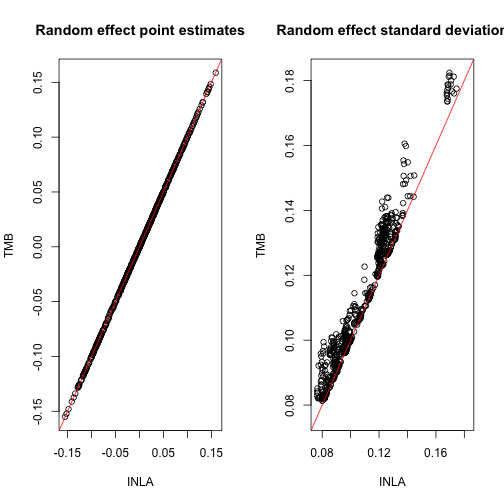

```r
par(mfrow = c(1, 2))

plot(inlafit13$summary.random[[1]][,2],
     sdr13sum[rownames(sdr13sum) == "u_space_time", 1],
     xlab = "INLA", ylab = "TMB", main = "Random effect point estimates")
abline(0, 1, col = "red")

x <- inlafit13$summary.random[[1]][,3]
y <- sdr13sum[rownames(sdr13sum) == "u_space_time", 2]
plot(x, y,
     xlab = "INLA", ylab = "TMB", main = "Random effect standard deviation",
     xlim = range(c(x, y)), ylim = range(c(x, y)))
abline(0, 1, col = "red")
```